# Business Statistics Mid-Term Assessment IB94X0 2024-2025 #2

5594410

## Certification Of Original Work

This is to certify that the work I am submitting is my own. I am aware of the University of Warwick regulation concerning plagiarism and collusion.

No substantial part(s) of the work submitted here has also been submitted by me in other assessments for accredited courses of study, and I acknowledge that if this has been done an appropriate reduction in the mark I might otherwise have received will be made.

AI was used in the preparation of this work. It was used in the development of the code: It was used to provide example uses of functions or approaches to elements of the challenges which were then interpreted by me and modified to be applicable to this data/report.

## Question 1 - Cardio Vascular Disease In England

### *Project Overview*

This report aims to identify which factors—overweight, smoking, wellbeing, and poverty impact the prevalence of cardiovascular disease (CVD) in an area, by performing the below specific analyses:

1. Provide a data integrity check of the dataset.
2. Provide a data quality check of the dataset.
3. Perform correlation of the dependent variable (`cvd`) with each independent variable (`poverty`, `smokers`, `wellbeing`, and `overweight`).
4. Perform linear regression of the dependent variable (`cvd`) with each independent variable (`poverty`, `smokers`, `wellbeing`, and `overweight`) and plot the results.
5. Perform multiple linear regression for all independent variables (`poverty`, `smokers`, `wellbeing`, `overweight`) against the dependent variable (`cvd`).
6. Perform NHST (Null Hypothesis Significance Testing) for the regression coefficients of the multiple linear regression model.
7. Perform the estimation approach for the multiple regression model.
8. Calculate the Variance Inflation Factor (VIF) to check for multicollinearity.
9. Perform EMEANS analysis to assess the adjusted means of CVD prevalence across different levels of each independent variable.
10. Plot the effect of poverty on cardiovascular disease (`cvd`).

### *Data Dictionary*

This dataset comprises of data collected from various datasets from the UK Office for National Statistics. Each row in the dataset represents a local authority region and contains the following variables:

| Variable | Description |
| --- | --- |
| area_name | Name of the specific local authority region. |
| area_code | A distinctive identifier assigned to each local authority region. |
| Population | The total count of people living in the local authority region. |
| Poverty | The percentage of residents in the region identified as living in poverty. |
| CVD | The share of the population recently affected by Cardiovascular Disease |
| overweight | The percentage of residents categorized as overweight. |
| smokers | The proportion of individuals in the region who are smokers. |
| wellbeing | The average wellbeing rating of the residents in the region. |

### *Load Libraries*

```r
# Load necessary libraries
library(tidyverse)  # For data manipulation and visualization
library(kableExtra) # For creating and customizing tables
library(ggplot2) # For creating graphics and visualizations
library(patchwork)  # For combining plots into a grid
library(car)        # For Anova tests and multicollinearity diagnostics
library(interactions) # For visualizing interaction effects
library(knitr) # For better table output
library(broom) # For tidying statistical outputs
library(gridExtra) #For arranging multiple plots in a grid layout
library(emmeans) # Load the emmeans library to compute estimated marginal means (EMMs)
library(grid) # For creating custom plots, controlling graphical elements, and arranging complex layouts.
options(width=100)  # Set console output width
```

### *Read Dataset*

```r
 #1. Read the cardio vascular disease dataset (Cardio_Vascular_Disease.csv)
cardio_vasc <- read_csv("Cardio_Vascular_Disease.csv")
#2. Display the first five rows of the dataset for an overview
head(cardio_vasc)
```

```
## # A tibble: 6 × 8
##   area_name            area_code Population Poverty   CVD overweight smokers wellbeing
##   <chr>                <chr>          <dbl>   <dbl> <dbl>      <dbl>   <dbl>     <dbl>
## 1 Hartlepool           E06000001      88905    23    13.7       34.6    17.3      7.33
## 2 Middlesbrough        E06000002     133375    25.1  13.1       32.0    17.9      7.21
## 3 Redcar and Cleveland E06000003     131035    21.4  15         33.4    13.3      7.44
## 4 Stockton-on-Tees     E06000004     186365    19.5  12.4       40.2    12.5      7.4
## 5 Darlington           E06000005     104300    19.7  11.9       35.7    10.6      7.25
## 6 Halton               E06000006     125725    21.9  15.7       32.3    13.2      7.29
```

### *Data Integrity*

```r
#1. Display the structure of the 'cardio_vasc' dataset
# This will show the data type, number of observations, variable names, and a preview of the data.
str(cardio_vasc)
```

```
## spc_tbl_ [385 × 8] (S3: spec_tbl_df/tbl_df/tbl/data.frame)
##  $ area_name : chr [1:385] "Hartlepool" "Middlesbrough" "Redcar and Cleveland" "Stockton-on-Tees" ...
##  $ area_code : chr [1:385] "E06000001" "E06000002" "E06000003" "E06000004" ...
##  $ Population: num [1:385] 88905 133375 131035 186365 104300 ...
##  $ Poverty   : num [1:385] 23 25.1 21.4 19.5 19.7 21.9 17.9 24.9 26.1 22.4 ...
##  $ CVD       : num [1:385] 13.7 13.1 15 12.4 11.9 15.7 12 13.4 17.6 11.2 ...
##  $ overweight: num [1:385] 34.6 32 33.4 40.2 35.7 ...
##  $ smokers   : num [1:385] 17.3 17.9 13.3 12.5 10.6 13.2 10 15.5 20.6 22 ...
##  $ wellbeing : num [1:385] 7.33 7.21 7.44 7.4 7.25 7.29 7.21 7.43 7.16 7.14 ...
##  - attr(*, "spec")=
##   .. cols(
##   ..   area_name = col_character(),
##   ..   area_code = col_character(),
##   ..   Population = col_double(),
##   ..   Poverty = col_double(),
##   ..   CVD = col_double(),
##   ..   overweight = col_double(),
##   ..   smokers = col_double(),
##   ..   wellbeing = col_double()
##   .. )
##  - attr(*, "problems")=<externalptr>
```

```r
#2. Display a summary of the 'cardio_vasc' dataset
# This provides statistics (e.g., mean, median, min, max) for each variable in the dataset.
summary(cardio_vasc)
```

```
##   area_name          area_code           Population         Poverty           CVD
##  Length:385         Length:385         Min.   :   1960   Min.   :12.90   Min.   : 7.90
##  Class :character   Class :character   1st Qu.: 100640   1st Qu.:16.90   1st Qu.:10.90
##  Mode  :character   Mode  :character   Median : 135275   Median :18.70   Median :12.30
##                                        Mean   : 174804   Mean   :19.34   Mean   :12.42
##                                        3rd Qu.: 216600   3rd Qu.:21.40   3rd Qu.:14.10
##                                        Max.   :1056970   Max.   :30.70   Max.   :17.80
##                                        NA's   :76        NA's   :76      NA's   :76
##    overweight       smokers        wellbeing
##  Min.   :10.24   Min.   : 3.20   Min.   :6.610
##  1st Qu.:21.63   1st Qu.:10.72   1st Qu.:7.280
##  Median :25.52   Median :12.80   Median :7.410
##  Mean   :25.52   Mean   :13.07   Mean   :7.423
##  3rd Qu.:29.46   3rd Qu.:15.30   3rd Qu.:7.560
##  Max.   :40.22   Max.   :27.80   Max.   :8.170
##  NA's   :72      NA's   :7       NA's   :15
```

```r
#3. Standardize column names
# Convert all column names to lowercase to ensure consistency.
colnames(cardio_vasc) <- tolower(colnames(cardio_vasc))

# View the modified dataset with updated column names
print(cardio_vasc)
```

```
## # A tibble: 385 × 8
##    area_name             area_code population poverty   cvd overweight smokers wellbeing
##    <chr>                 <chr>          <dbl>   <dbl> <dbl>      <dbl>   <dbl>     <dbl>
##  1 Hartlepool            E06000001      88905    23    13.7       34.6    17.3      7.33
##  2 Middlesbrough         E06000002     133375    25.1  13.1       32.0    17.9      7.21
##  3 Redcar and Cleveland  E06000003     131035    21.4  15         33.4    13.3      7.44
##  4 Stockton-on-Tees      E06000004     186365    19.5  12.4       40.2    12.5      7.4
##  5 Darlington            E06000005     104300    19.7  11.9       35.7    10.6      7.25
##  6 Halton                E06000006     125725    21.9  15.7       32.3    13.2      7.29
##  7 Warrington            E06000007     205450    17.9  12         26.1    10        7.21
##  8 Blackburn with Darwen E06000008     147180    24.9  13.4       26.3    15.5      7.43
##  9 Blackpool             E06000009     134135    26.1  17.6       37.2    20.6      7.16
## 10 Kingston upon Hull    E06000010     249770    22.4  11.2       35.3    22        7.14
## # ℹ 375 more rows
```

```r
#4. Format character columns
# Ensure that character columns are properly formatted by removing leading/trailing whitespaces.
character_columns <- names(cardio_vasc)[sapply(cardio_vasc, is.character)]
cardio_vasc[character_columns] <- lapply(cardio_vasc[character_columns], trimws)

#5. Check unique Values in the character columns
# Identify unique values in character columns like 'area_name' and 'area_code' to ensure data integrity.
unique(cardio_vasc[character_columns])
```

```
## # A tibble: 385 × 2
##    area_name             area_code
##    <chr>                 <chr>
##  1 Hartlepool            E06000001
##  2 Middlesbrough         E06000002
##  3 Redcar and Cleveland  E06000003
##  4 Stockton-on-Tees      E06000004
##  5 Darlington            E06000005
##  6 Halton                E06000006
##  7 Warrington            E06000007
##  8 Blackburn with Darwen E06000008
##  9 Blackpool             E06000009
## 10 Kingston upon Hull    E06000010
## # ℹ 375 more rows
```

```r
#6. Format numeric columns
# Convert specified numeric columns to the correct numeric format.
numeric_columns <- c("population", "poverty", "cvd", "overweight", "smokers", "wellbeing")
cardio_vasc[numeric_columns] <- lapply(cardio_vasc[numeric_columns], as.numeric)

#7. Verify logical consistency of numeric columns
# Check if numeric columns like 'poverty', 'cvd', etc, fall within valid ranges (0-100 for percentages).
columns_to_check <- c("poverty", "cvd", "overweight", "smokers")
cardio_vasc <- cardio_vasc[apply(cardio_vasc[, columns_to_check], 1, function(row) all(row >= 0 & row <= 100, na.rm = TRUE)), ]
```

### *Data Cleaning*

```r
#1. Identify duplicate rows
# This step checks for duplicate rows in the dataset by identifying duplicates from both the front and the back.
duplicates <- cardio_vasc %>% filter(duplicated(.) | duplicated(., fromLast = TRUE))

# Display any duplicate rows if found.
print(duplicates)
```

```
## # A tibble: 0 × 8
## # ℹ 8 variables: area_name <chr>, area_code <chr>, population <dbl>, poverty <dbl>, cvd <dbl>,
## #   overweight <dbl>, smokers <dbl>, wellbeing <dbl>
```

```r
#2. Round numeric columns
# Round specific numeric columns to two decimal places for precision and readability
cardio_vasc[, numeric_columns] <- lapply(cardio_vasc[, numeric_columns], round, 2)

# Print the updated data frame to review changes
print(cardio_vasc)
```

```
## # A tibble: 385 × 8
##    area_name             area_code population poverty   cvd overweight smokers wellbeing
##    <chr>                 <chr>          <dbl>   <dbl> <dbl>      <dbl>   <dbl>     <dbl>
##  1 Hartlepool            E06000001      88905    23    13.7       34.6    17.3      7.33
##  2 Middlesbrough         E06000002     133375    25.1  13.1       32.0    17.9      7.21
##  3 Redcar and Cleveland  E06000003     131035    21.4  15         33.4    13.3      7.44
##  4 Stockton-on-Tees      E06000004     186365    19.5  12.4       40.2    12.5      7.4
##  5 Darlington            E06000005     104300    19.7  11.9       35.7    10.6      7.25
##  6 Halton                E06000006     125725    21.9  15.7       32.3    13.2      7.29
##  7 Warrington            E06000007     205450    17.9  12         26.1    10        7.21
##  8 Blackburn with Darwen E06000008     147180    24.9  13.4       26.3    15.5      7.43
##  9 Blackpool             E06000009     134135    26.1  17.6       37.2    20.6      7.16
## 10 Kingston upon Hull    E06000010     249770    22.4  11.2       35.3    22        7.14
## # ℹ 375 more rows
```

```r
#3. Check for missing values (NA)
# Counts the number of missing (NA) values in each column of the dataset.
missing_count <- colSums(is.na(cardio_vasc))

# Display the count of missing values for each column.
print(missing_count)
```

```
##  area_name  area_code population    poverty        cvd overweight    smokers  wellbeing
##          0          0         76         76         76         72          7         15
```

```r
# Calculate the total missing values in the entire dataset.
print(sum(is.na(cardio_vasc)))
```

```
## [1] 322
```

```r
#4. Calculate the percentage of missing values for each column in order to calculate the impact
missing_values_percentages <-  cardio_vasc %>%
  summarise(across(everything(), ~sum(is.na(.)) / n()*100)) %>%
  pivot_longer(everything(), names_to = "column", values_to = "Missing_Percentage")
print(missing_values_percentages)
```

```
## # A tibble: 8 × 2
##   column     Missing_Percentage
##   <chr>                   <dbl>
## 1 area_name                0
## 2 area_code                0
## 3 population              19.7
## 4 poverty                 19.7
## 5 cvd                     19.7
## 6 overweight              18.7
## 7 smokers                  1.82
## 8 wellbeing                3.90
```

**Interpretation** :The table shows high missing rates in **population, poverty, and cvd (19.74%) and overweight (18.70%), likely due to gaps in data collection or reporting, this could weaken the reliability of insights**.

In contrast, **wellbeing (3.90%) and smokers (1.82%) have minimal missing values, reflecting better data consistency**. **Addressing these gaps is essential to reduce bias and ensure meaningful analysis of socioeconomic and health factors.**

```r
#5. Drop rows with missing values present in numeric columns
# This step removes rows where columns such as cvd, population, smokers, overweight, and others have missing values.
cleaned_cardio_vasc_data <- na.omit(cardio_vasc[, c("cvd", "population", "overweight", "poverty", "wellbeing", "smokers")])

# Display the cleaned dataset after removing rows with missing values.
print(cleaned_cardio_vasc_data)
```

```
## # A tibble: 303 × 6
##      cvd population overweight poverty wellbeing smokers
##    <dbl>      <dbl>      <dbl>   <dbl>     <dbl>   <dbl>
##  1  13.7      88905       34.6    23        7.33    17.3
##  2  13.1     133375       32.0    25.1      7.21    17.9
##  3  15       131035       33.4    21.4      7.44    13.3
##  4  12.4     186365       40.2    19.5      7.4     12.5
##  5  11.9     104300       35.7    19.7      7.25    10.6
##  6  15.7     125725       32.3    21.9      7.29    13.2
##  7  12       205450       26.1    17.9      7.21    10
##  8  13.4     147180       26.3    24.9      7.43    15.5
##  9  17.6     134135       37.2    26.1      7.16    20.6
## 10  11.2     249770       35.3    22.4      7.14    22
## # ℹ 293 more rows
```

**Interpretation of the removal of missing values**: The dataset has a total of **322 missing values**, with **population**, **poverty**, and **CVD** missing **19.74%**, and **overweight** **18.70%**. **These percentages are well above the commonly accepted threshold for imputation** (**<10%**), which **increases the likelihood** of **bias** or **distorted results**.

Moreover, the possibility of **non-random missing values further complicates the assumptions needed for reliable imputation**. **Eliminating these missing values**, though it reduces the **sample size**, ensures the **analysis stays accurate** and maintains the **validity** of relationships between **socioeconomic** and **health factors**.

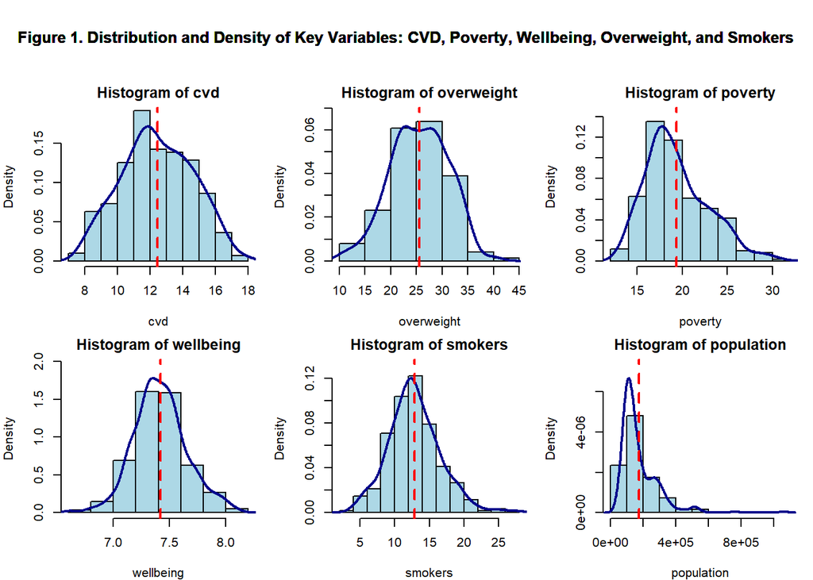

```r
#6. Visualize distributions of numeric columns("cvd", "overweight", "poverty", "wellbeing", "smokers", "population")
# This step generates histograms for columns of interest to visually inspect their distribution and density.

# Define the columns to plot
columns <- c("cvd", "overweight", "poverty", "wellbeing", "smokers", "population")

# Set up a 2x3 grid layout for the histograms
# Adjust outer margins to make space for the title
par(mfrow = c(2, 3),
oma = c(0, 0, 5, 0),
mar = c(4, 4, 2, 1))  # Adjust margins for better readability

# Loop through the specified columns and generate histograms with density curves
for (col in columns) {
  # Extract the data for the current column
  column_data <- cleaned_cardio_vasc_data[[col]]

  # Calculate the density for the column data
  density_data <- density(column_data)

  # Plot the histogram and adjust the y-axis limit
  hist(column_data, probability = TRUE, col = "lightblue",
       main = paste("Histogram of", col),
       xlab = col,
       ylim = c(0, max(density_data$y) * 1.1))  # Add 10% padding to the density peak

  # Add the density curve to the histogram
  lines(density_data, col = "darkblue", lwd = 2)

  # Add a vertical line to indicate the mean of the data
  abline(v = mean(column_data), col = "red", lwd = 2, lty = 2)

  mtext("Figure 1. Distribution and Density of Key Variables: CVD, Poverty, Wellbeing, Overweight, and Smokers",
      side = 3, outer = TRUE, line = 2, cex = 0.80, font = 2)
}
```

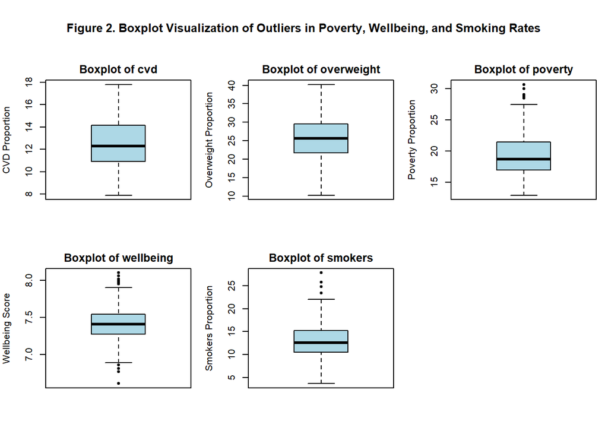

```r
#7. Detect and review outliers

# Adjust layout for a grid of two rows and three columns
par(mfrow = c(2, 3),            # Set the layout for 2 rows and 3 columns of plots
    mar = c(4, 4, 2, 1),        # Set the margins for individual plots (bottom, left, top, right)
    oma = c(0, 0, 5, 0))        # Set the outer margins for the entire plot grid (for the title)

# Specify the columns to generate boxplots for
selected_columns <- c("cvd", "overweight", "poverty", "wellbeing", "smokers")

# Define custom y-axis labels for each of the selected columns
y_labels <- c(
  "overweight" = "Overweight Proportion",   # Label for the 'overweight' column
  "poverty" = "Poverty Proportion",         # Label for the 'poverty' column
  "wellbeing" = "Wellbeing Score",          # Label for the 'wellbeing' column
  "smokers" = "Smokers Proportion",         # Label for the 'smokers' column
  "cvd" = "CVD Proportion"                  # Label for the 'cvd' column
)

# Loop through each selected column to generate individual boxplots
for (col in selected_columns) {
  # Generate a boxplot for the current column
  boxplot(cleaned_cardio_vasc_data[[col]],
          main = paste("Boxplot of", col),  # Add a title for each boxplot
          col = "lightblue",               # Set the box color to light blue
          xlab = "",                       # Suppress the x-axis label
          ylab = y_labels[[col]],          # Use the custom y-axis label
          xaxt = "n",                 # Suppress the x-axis ticks and labels
          outpch = 20,                     # Use solid circles for outliers
          outcex = 1,                      # Set the size of the outliers
          outcol = "black"                 # Set the color of outliers to black
  )
}

# Add a main title for the entire grid of plots
mtext("Figure 2. Boxplot Visualization of Outliers in Poverty, Wellbeing, and Smoking Rates",
      side = 3,           # Position the title on the top side
      outer = TRUE,       # Place the title in the outer margin
      line = 2,           # Adjust the line position of the title
      cex = 0.80, font = 2)  # Set the size of the title text
```

These outliers represent areas with **exceptionally high or low socioeconomic or health measures**, and **removing them could obscure valuable insights.** The **population variable** wasn’t included in the boxplot as it’s not directly relevant to this analysis.

**Retaining these outliers ensures the analysis accounts** for the **full range of variations**, providing a more **accurate and meaningful understanding** of the data.

### *Correlation Analysis*

```r
# Define the continuous numeric columns to analyze
numeric_columns <- c("cvd", "overweight", "smokers", "wellbeing", "poverty")

# Compute and display the Pearson correlation matrix
pearson_corr_matrix <- cor(cleaned_cardio_vasc_data[, numeric_columns], method = "pearson", use = "complete.obs")
print("Pearson Correlation Coefficients:")
```

```
## [1] "Pearson Correlation Coefficients:"
```

```r
print(pearson_corr_matrix)
```

```
##                   cvd  overweight    smokers   wellbeing    poverty
## cvd         1.0000000  0.31895982  0.1778206  0.24536584 -0.2480841
## overweight  0.3189598  1.00000000  0.4033779 -0.04179666  0.1393826
## smokers     0.1778206  0.40337794  1.0000000 -0.19895474  0.3613067
## wellbeing   0.2453658 -0.04179666 -0.1989547  1.00000000 -0.3451039
## poverty    -0.2480841  0.13938263  0.3613067 -0.34510391  1.0000000
```

**Interpretation:** The analysis reveals several key correlations related to **CVD prevalence**:

- **CVD and Overweight (r = 0.319)**: There’s a noticeable connection between **overweight** rates and **CVD** cases. This makes sense because we know that carrying extra weight can lead to heart problems, mainly through things like **high blood pressure** and **cholesterol issues**.
- **CVD and Smoking (r = 0.178)**: The link between **smoking** and **CVD** is weaker here, which could mean that while smoking is a risk factor, other factors, like **healthcare access** or other lifestyle habits, might play a bigger role in this case.
- **CVD and Wellbeing (r = 0.246)**: It’s interesting that areas with higher **wellbeing** scores also tend to report more **CVD** cases. This might be because these regions have better **healthcare** systems, so people are more likely to get diagnosed and reported for heart disease.
- **CVD and Poverty (r = -0.248)**: There’s a surprising trend where **CVD** rates seem lower in poorer areas. This could be due to **under-reporting** or lack of access to proper healthcare, rather than poverty itself protecting against heart disease.
- **Poverty and Wellbeing (r = -0.345)**: A strong link shows that higher **poverty** levels are tied to lower **wellbeing**. This is a reminder of how financial struggles can affect both **mental** and **physical health**, making it harder for people in low-income areas to stay healthy.

### *Linear Regression: CVD vs Poverty*

```r
# Fit the linear regression model
# This model predicts cardiovascular disease (CVD) prevalence based on poverty percentage.
lm.cvd.by.poverty <- lm(cvd ~ poverty, data = cleaned_cardio_vasc_data)

# Display a summary of the regression model
# The summary includes coefficients, R-squared value, p-values, and more.
summary(lm.cvd.by.poverty)
```

```
##
## Call:
## lm(formula = cvd ~ poverty, data = cleaned_cardio_vasc_data)
##
## Residuals:
##     Min      1Q  Median      3Q     Max
## -4.3405 -1.7342 -0.3115  1.5837  6.1954
##
## Coefficients:
##             Estimate Std. Error t value Pr(>|t|)
## (Intercept)  15.4399     0.6844  22.558  < 2e-16 ***
## poverty      -0.1546     0.0348  -4.443 1.25e-05 ***
## ---
## Signif. codes:  0 '***' 0.001 '**' 0.01 '*' 0.05 '.' 0.1 ' ' 1
##
## Residual standard error: 2.107 on 301 degrees of freedom
## Multiple R-squared:  0.06155,    Adjusted R-squared:  0.05843
## F-statistic: 19.74 on 1 and 301 DF,  p-value: 1.248e-05
```

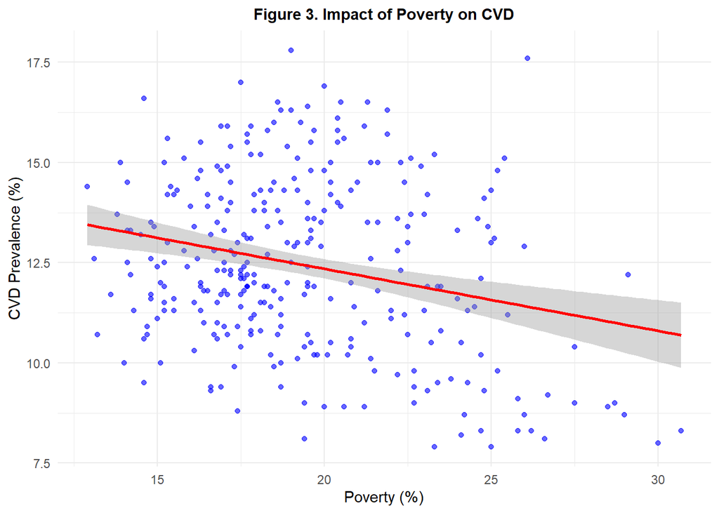

```r
# Create a scatter plot with a regression line
plot_poverty <- ggplot(cleaned_cardio_vasc_data, aes(x = poverty, y = cvd)) +
  # Add points to represent data, with blue color and some transparency
  geom_point(color = "blue", alpha = 0.6) +
  # Add a linear regression line with confidence interval shaded
  geom_smooth(method = "lm", color = "red", se = TRUE) +
  # Add labels for the plot, x-axis, and y-axis
  labs(title = "Figure 3. Impact of Poverty on CVD",
       x = "Poverty (%)",
       y = "CVD Prevalence (%)") +
  # Apply a minimalistic theme for a clean look
  theme_minimal() +
theme(
    plot.title = element_text(hjust = 0.5, size = 11, face = "bold")) # Center-align title

# Print the plot to visualize the relationship
print(plot_poverty)
```

**Interpretation:**

The analysis reveals a **statistically significant negative relationship** between **poverty** and **CVD prevalence**. For every **1% increase in poverty**, **CVD prevalence decreases** by **0.15%** (**t(301) = -4.44, p < 0.0001**), indicating a reliable inverse association.

The **downward-sloping regression line** in **Figure 3**, along with the confidence interval, supports this trend, though with moderate variability.

This relationship may be due to factors such as **under-diagnosis**, **limited healthcare access**, or **demographic differences** in poorer areas, where cardiovascular diseases may not be accurately reported or diagnosed.

### *Linear Regression: CVD vs Wellbeing*

```r
# Fit the linear regression model
# This model predicts cardiovascular disease (CVD) prevalence based on wellbeing scores.
lm.cvd.by.wellbeing <- lm(cvd ~ wellbeing, data = cleaned_cardio_vasc_data)

# Display a summary of the regression model
# The summary includes regression coefficients, p-values, R-squared, and diagnostic statistics.
summary(lm.cvd.by.wellbeing)
```

```
##
## Call:
## lm(formula = cvd ~ wellbeing, data = cleaned_cardio_vasc_data)
##
## Residuals:
##     Min      1Q  Median      3Q     Max
## -4.7102 -1.4962 -0.1551  1.6471  5.7299
##
## Coefficients:
##             Estimate Std. Error t value Pr(>|t|)
## (Intercept)  -4.1872     3.7900  -1.105     0.27
## wellbeing     2.2426     0.5107   4.391 1.56e-05 ***
## ---
## Signif. codes:  0 '***' 0.001 '**' 0.01 '*' 0.05 '.' 0.1 ' ' 1
##
## Residual standard error: 2.108 on 301 degrees of freedom
## Multiple R-squared:  0.0602, Adjusted R-squared:  0.05708
## F-statistic: 19.28 on 1 and 301 DF,  p-value: 1.563e-05
```

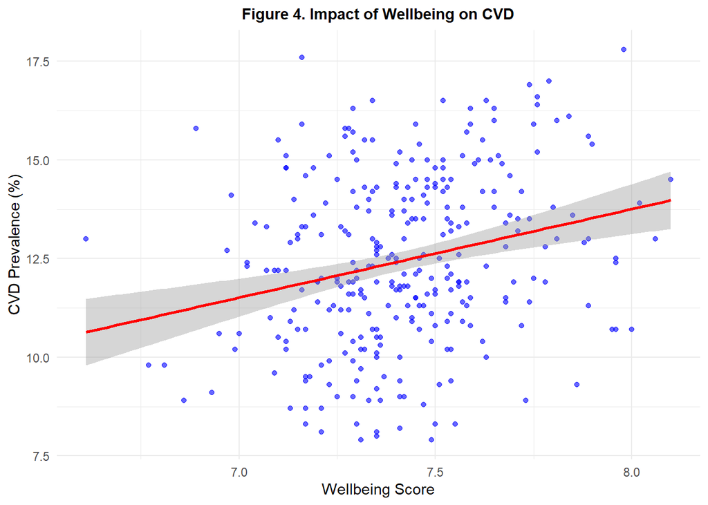

```r
# Create a scatter plot with a regression line
plot_wellbeing <- ggplot(cleaned_cardio_vasc_data, aes(x = wellbeing, y = cvd))  +
  # Add points to represent data, with blue color and some transparency
  geom_point(color = "blue", alpha = 0.6) +
  # Add a linear regression line with confidence interval shaded
  geom_smooth(method = "lm", color = "red", se = TRUE) +
  # Add labels for the plot, x-axis, and y-axis
  labs(title = "Figure 4. Impact of Wellbeing on CVD",
       x = "Wellbeing Score",
       y = "CVD Prevalence (%)") +
  # Apply a minimalistic theme for a clean look
  theme_minimal() +
theme(
    plot.title = element_text(hjust = 0.5, size = 11, face = "bold")) # Center-align title

# Print the plot to visualize the relationship
print(plot_wellbeing)
```

**Interpretation:**

The analysis shows a **statistically significant positive relationship** between **wellbeing scores** and **CVD prevalence**. For every **1 unit increase in wellbeing scores**, CVD prevalence rises by **2.24%** (**t(301) = 4.39, p < 0.0001**), indicating a reliable connection.

The **upward-sloping regression line** in **Figure 4** and the narrow **confidence interval** confirm the consistency of this trend.

This relationship could reflect **socioeconomic dynamics** or differences in **healthcare access**, where areas with higher wellbeing scores might also have more **CVD diagnoses** due to better healthcare infrastructure or more accurate reporting.

### *Linear Regression: CVD vs Smokers*

```r
# Fit the linear regression model
# This model predicts cardiovascular disease (CVD) prevalence based on the percentage of smokers.
lm.cvd.by.smokers <- lm(cvd ~ smokers, data = cleaned_cardio_vasc_data)

# Display a summary of the regression model
# The summary provides regression coefficients, R-squared, p-values, and other diagnostics.
summary(lm.cvd.by.smokers)
```

```
##
## Call:
## lm(formula = cvd ~ smokers, data = cleaned_cardio_vasc_data)
##
## Residuals:
##     Min      1Q  Median      3Q     Max
## -4.7038 -1.3878 -0.1537  1.6257  5.5031
##
## Coefficients:
##             Estimate Std. Error t value Pr(>|t|)
## (Intercept) 11.13068    0.43746  25.444  < 2e-16 ***
## smokers      0.10230    0.03263   3.135  0.00189 **
## ---
## Signif. codes:  0 '***' 0.001 '**' 0.01 '*' 0.05 '.' 0.1 ' ' 1
##
## Residual standard error: 2.14 on 301 degrees of freedom
## Multiple R-squared:  0.03162,    Adjusted R-squared:  0.0284
## F-statistic: 9.828 on 1 and 301 DF,  p-value: 0.001888
```

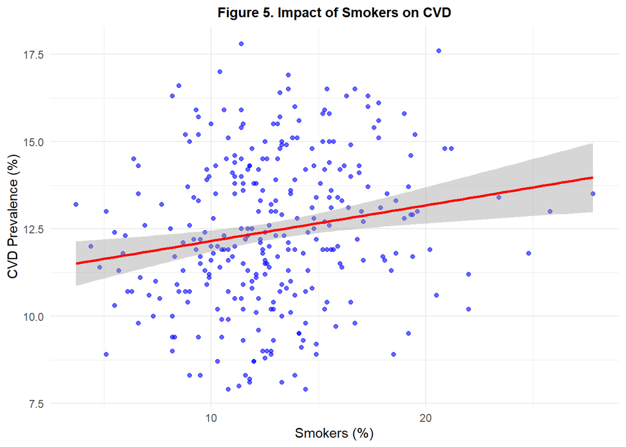

```r
# Create a scatter plot with a regression line
plot_smokers <- ggplot(cleaned_cardio_vasc_data, aes(x = smokers, y = cvd))  +
  # Add points to represent data, with blue color and some transparency
  geom_point(color = "blue", alpha = 0.6) +
  # Add a linear regression line with confidence interval shaded
  geom_smooth(method = "lm", color = "red", se = TRUE) +
  # Add labels for the plot, x-axis, and y-axis
  labs(title = "Figure 5. Impact of Smokers on CVD",
       x = "Smokers (%)",
       y = "CVD Prevalence (%)") +
  # Apply a minimalistic theme for a clean look
  theme_minimal() +
theme(
    plot.title = element_text(hjust = 0.5, size = 11, face = "bold")) # Center-align title

# Print the plot to visualize the relationship
print(plot_smokers)
```

**Interpretation:**

The analysis shows a **statistically significant positive relationship** between **smoking** and **CVD prevalence**. For every **1% increase in smoking rates**, CVD prevalence rises by **0.10%** (**t(301) = 3.14, p = 0.0019**), confirming a strong and reliable connection.

The **upward-sloping regression line** in **Figure 5** supports this relationship, with a narrow **confidence interval** highlighting the consistency of the trend.

Smoking is a well-established cause of **cardiovascular disease**, contributing to **blood vessel damage**, **inflammation**, and **plaque buildup**, all of which significantly harm heart health.

### *Linear Regression: CVD vs Overweight*

```r
# Fit the linear regression model
# This model predicts cardiovascular disease (CVD) prevalence based on the percentage of overweight individuals.
lm.cvd.by.overweight <- lm(cvd ~ overweight, data = cleaned_cardio_vasc_data)

# Display a summary of the regression model
# The summary provides details about the regression coefficients, R-squared value, p-values, and other statistics.
summary(lm.cvd.by.overweight)
```

```
##
## Call:
## lm(formula = cvd ~ overweight, data = cleaned_cardio_vasc_data)
##
## Residuals:
##     Min      1Q  Median      3Q     Max
## -4.8288 -1.5187 -0.1371  1.5366  5.4851
##
## Coefficients:
##             Estimate Std. Error t value Pr(>|t|)
## (Intercept)  9.29564    0.55255  16.823  < 2e-16 ***
## overweight   0.12336    0.02113   5.839 1.36e-08 ***
## ---
## Signif. codes:  0 '***' 0.001 '**' 0.01 '*' 0.05 '.' 0.1 ' ' 1
##
## Residual standard error: 2.061 on 301 degrees of freedom
## Multiple R-squared:  0.1017, Adjusted R-squared:  0.09875
## F-statistic: 34.09 on 1 and 301 DF,  p-value: 1.362e-08
```

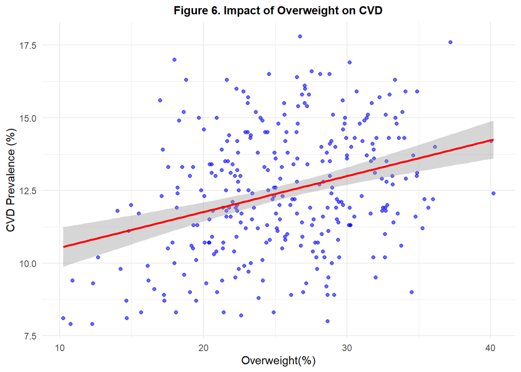

```r
# Create a scatter plot with a regression line
plot_overweight <- ggplot(cleaned_cardio_vasc_data, aes(x = overweight, y = cvd)) +
  # Add points to represent data, with blue color and some transparency
  geom_point(color = "blue", alpha = 0.6) +
  # Add a linear regression line with confidence interval shaded
  geom_smooth(method = "lm", color = "red", se = TRUE) +
  # Add labels for the plot, x-axis, and y-axis
  labs(title = "Figure 6. Impact of Overweight on CVD",
       x = "Overweight(%)",
       y = "CVD Prevalence (%)") +
  # Apply a minimalistic theme for a clean look
  theme_minimal() +
theme(
    plot.title = element_text(hjust = 0.5, size = 11, face = "bold")) # Center-align title

# Print the plot to visualize the relationship
print(plot_overweight)
```

**Interpretation:**

The analysis shows that for every 1% increase in overweight individuals, **CVD prevalence** rises by 0.12% (t(301) = 5.84, p < 0.001), indicating a strong and reliable connection.

**Figure 6** clearly shows this trend with an upward-sloping line and a tight **confidence interval**, which reinforces the consistency of the results.

Being **overweight** is a major risk factor for **CVD**, contributing to issues like **high blood pressure**, **cholesterol imbalances**, and **inflammation**, all of which are directly linked to heart disease.

### *All Linear Regressions*

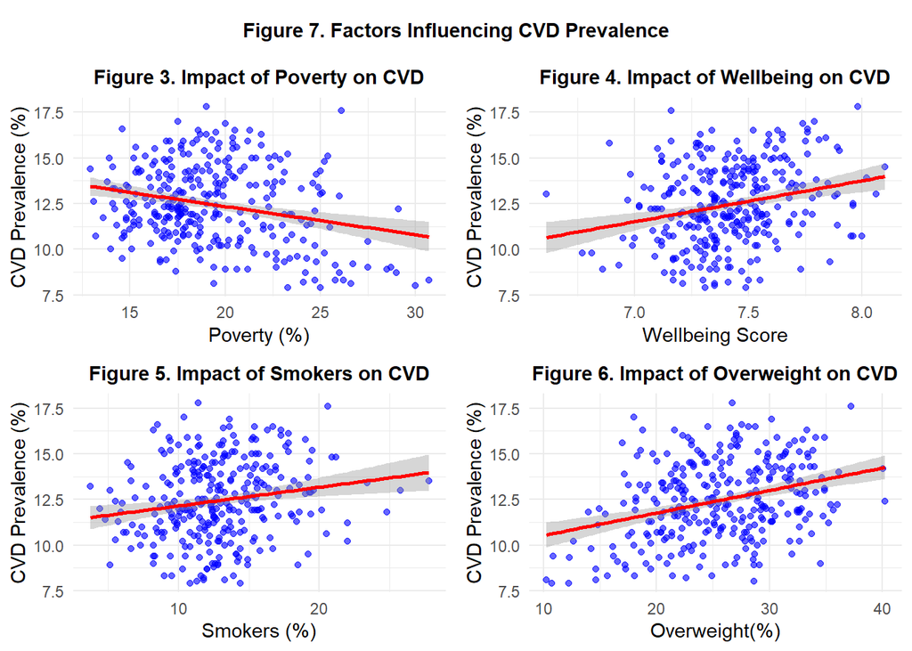

```r
title <- textGrob(
  "Figure 7. Factors Influencing CVD Prevalence",
  gp = gpar(fontsize = 11, fontface = "bold")
)

# Arrange the plots using grid.arrange
grid.arrange(
  title,
  arrangeGrob(plot_poverty,plot_wellbeing, plot_smokers, plot_overweight, ncol = 2),  # Arrange individual plots in a grid
  nrow = 2, heights = c(0.1,1)          # Adjust height to fit the title
)
```

**Interpretation:** **Figure 7** looks at how **CVD prevalence** is affected by four key factors: **poverty**, **overweight**, **smoking**, and **wellbeing**.

- **Poverty** shows a surprising **negative relationship** with **CVD**, meaning that in areas with higher poverty, CVD rates are lower. This might be influenced by factors like **healthcare access** or **lifestyle differences** that we can’t fully capture in the data.
- Both **overweight** and **smoking** have a **positive relationship** with **CVD**, which is expected. Being overweight or smoking increases the risk of conditions like **hypertension** and **diabetes**, which are major contributors to **CVD**.
- **Wellbeing** also shows a positive relationship with **CVD**, which is unexpected. This could be because people living with CVD might report feeling better overall, or it could reflect other factors like **health awareness** in certain groups.

In conclusion, while **overweight** and **smoking** are clear contributors to **CVD**, the roles of **poverty** and **wellbeing** are more complex and need further exploration to fully understand their impact.

### *Multiple Linear Regression*

```r
# Fit a multiple regression model
# This model predicts CVD prevalence based on multiple predictors: overweight, smokers, wellbeing, and poverty.
multiple_regress_model <- lm(cvd ~ overweight + smokers + wellbeing + poverty, data = cleaned_cardio_vasc_data)

# Display the regression summary
# Provides coefficients for each predictor, p-values, R-squared, and overall model significance.
summary(multiple_regress_model)
```

```
##
## Call:
## lm(formula = cvd ~ overweight + smokers + wellbeing + poverty,
##     data = cleaned_cardio_vasc_data)
##
## Residuals:
##     Min      1Q  Median      3Q     Max
## -4.3961 -1.4310 -0.1098  1.3903  4.7781
##
## Coefficients:
##             Estimate Std. Error t value Pr(>|t|)
## (Intercept) -1.69619    3.93366  -0.431 0.666636
## overweight   0.10984    0.02123   5.173 4.24e-07 ***
## smokers      0.12031    0.03366   3.574 0.000410 ***
## wellbeing    1.80010    0.49097   3.666 0.000291 ***
## poverty     -0.18401    0.03515  -5.234 3.13e-07 ***
## ---
## Signif. codes:  0 '***' 0.001 '**' 0.01 '*' 0.05 '.' 0.1 ' ' 1
##
## Residual standard error: 1.894 on 298 degrees of freedom
## Multiple R-squared:  0.2493, Adjusted R-squared:  0.2393
## F-statistic: 24.75 on 4 and 298 DF,  p-value: < 2.2e-16
```

In summary, while **overweight** and **smoking** clearly contribute to **CVD prevalence**, the role of **wellbeing** and **poverty** shows that the relationship is more complex, influenced by factors like healthcare access, reporting practices, and regional disparities.

### *Null Hypothesis Significant Testing: Multiple Regression Model Coefficients*

```r
# Display the summary of the multiple regression model
# Provides coefficients, p-values, and R-squared to evaluate the significance and impact of each predictor.
summary(multiple_regress_model)
```

```
##
## Call:
## lm(formula = cvd ~ overweight + smokers + wellbeing + poverty,
##     data = cleaned_cardio_vasc_data)
##
## Residuals:
##     Min      1Q  Median      3Q     Max
## -4.3961 -1.4310 -0.1098  1.3903  4.7781
##
## Coefficients:
##             Estimate Std. Error t value Pr(>|t|)
## (Intercept) -1.69619    3.93366  -0.431 0.666636
## overweight   0.10984    0.02123   5.173 4.24e-07 ***
## smokers      0.12031    0.03366   3.574 0.000410 ***
## wellbeing    1.80010    0.49097   3.666 0.000291 ***
## poverty     -0.18401    0.03515  -5.234 3.13e-07 ***
## ---
## Signif. codes:  0 '***' 0.001 '**' 0.01 '*' 0.05 '.' 0.1 ' ' 1
##
## Residual standard error: 1.894 on 298 degrees of freedom
## Multiple R-squared:  0.2493, Adjusted R-squared:  0.2393
## F-statistic: 24.75 on 4 and 298 DF,  p-value: < 2.2e-16
```

**Interpretation:** The NHST results reveal that all predictors significantly influence CVD prevalence:

**Overweight** and **smoking both show small but reliable positive associations, with increases in each leading to higher CVD prevalence (0.11 and 0.12 increases, respectively, p < 0.001)**.

**Wellbeing has the strongest positive impact**, with a **1.80 increase** in CVD prevalence for every unit increase (**p < 0.001**).

Interestingly, **poverty shows a negative relationship**, with a **0.18 decrease** in CVD prevalence for every unit increase (**p < 0.001**), suggesting a complex or regional influence.

These findings confirm the significant and unique contributions of each factor to CVD prevalence.

### *Estimation Approach: Multiple Regression Model Coefficients*

```r
# Extract coefficients and confidence intervals
estimation_results <- tidy(multiple_regress_model, conf.int = TRUE)

# Rename columns for clarity
colnames(estimation_results) <- c("Predictor", "Coefficient", "Std.Error", "Statistic", "P-value", "95% CI Lower", "95% CI Upper")

# Select relevant columns for display
estimation_results <- estimation_results[, c("Predictor", "Coefficient", "95% CI Lower", "95% CI Upper")]

kable_table <- estimation_results %>%
  kable("html", digits = 3, col.names = c("Variable", "Estimate", "Lower 95% CI", "Upper 95% CI"), caption = "<span style='font-size:12px; font-weight:bold; color:black';>Figure 8. Coefficients and 95% Confidence Intervals</span>") %>%
  kable_styling(
    bootstrap_options = c("striped", "hover", "condensed", "responsive"),
    full_width = FALSE,
    font_size = 12,
    position = "center",
    latex_options = "HOLD_position"
  ) %>%
  column_spec(1, bold = TRUE) %>% # Make the first column bold
  row_spec(0, bold = TRUE, background = "#D3D3D3") # Bold header row with background color

# Display the table
kable_table
```

Figure 8. Coefficients and 95% Confidence Intervals

| Variable | Estimate | Lower 95% CI | Upper 95% CI |
| --- | --- | --- | --- |
| (Intercept) | -1.696 | -9.437 | 6.045 |
| overweight | 0.110 | 0.068 | 0.152 |
| smokers | 0.120 | 0.054 | 0.187 |
| wellbeing | 1.800 | 0.834 | 2.766 |
| poverty | -0.184 | -0.253 | -0.115 |

**Interpretation:** Figure 8 shows that all predictors are statistically significant, with confidence intervals excluding zero.

**Wellbeing has the largest positive effect** (**Estimate = 1.800, 95% CI = [0.834, 2.766]**), **indicating a strong increase in the outcome for each unit increase.**

**Poverty negatively affects the outcome** (**Estimate = -0.184, 95% CI = [-0.253, -0.115]**), while **overweight** (**Estimate = 0.110**) and **smokers (Estimate = 0.120) show smaller positive effects**, suggesting modest increases in the dependent variable.

### *Variance Inflation Factor (VIF): Detecting Multicollinearity*

```r
# Calculate Variance Inflation Factor (VIF) for the predictors in the multiple regression model
vif_values <- vif(multiple_regress_model)

# Display the VIF values for each predictor
cat("Variance Inflation Factor (VIF) for CVD Predictors:\n")
```

```
## Variance Inflation Factor (VIF) for CVD Predictors:
```

```r
print(vif_values)
```

```
## overweight    smokers  wellbeing    poverty
##   1.196573   1.359219   1.145512   1.263094
```

**Interpretation:** The **Variance Inflation Factor (VIF)** indicates minimal multicollinearity in this dataset. With VIF values of **overweight = 1.20, smokers = 1.36, wellbeing = 1.15, poverty = 1.26**, all are close to **1**, **meaning the predictors are largely independent and provide unique insights into the outcome variable.**

**No corrective actions are needed.**

**Interpretation thresholds**:  
- **VIF > 10**: High multicollinearity, corrective actions needed.  
- **VIF > 5**: Moderate multicollinearity, evaluate carefully.  
- **VIF close to 1**: Minimal multicollinearity, predictors are independent.

### *Estimated Marginal Means (EMMs) for Factors*

```r
 # Compute estimated marginal means (EMMs) for the specified factors in the model
model_emmeans <- emmeans(multiple_regress_model, ~overweight + poverty + smokers + wellbeing)

# Print the estimated marginal means result
print(model_emmeans)
```

```
##  overweight poverty smokers wellbeing emmean    SE  df lower.CL upper.CL
##        25.5    19.4    12.9      7.42   12.4 0.109 298     12.2     12.7
##
## Confidence level used: 0.95
```

**Interpretation**: The **Estimated Marginal Means (EMMs)** show that with specific factor levels (**overweight = 25.5, poverty = 19.4, smokers = 12.9, wellbeing = 7.42**), the average predicted outcome is **12.4**. The **small standard error (0.109)** indicates precision, and the **95% confidence interval ([12.2, 12.7])** suggests the true average lies within this range.

These values reflect how the model predicts outcomes based on these factors, though they show an **association**, **not causation**, and depend on the model’s accuracy.

### *Effect of Poverty on Cardio Vascular Disease (CVD)*

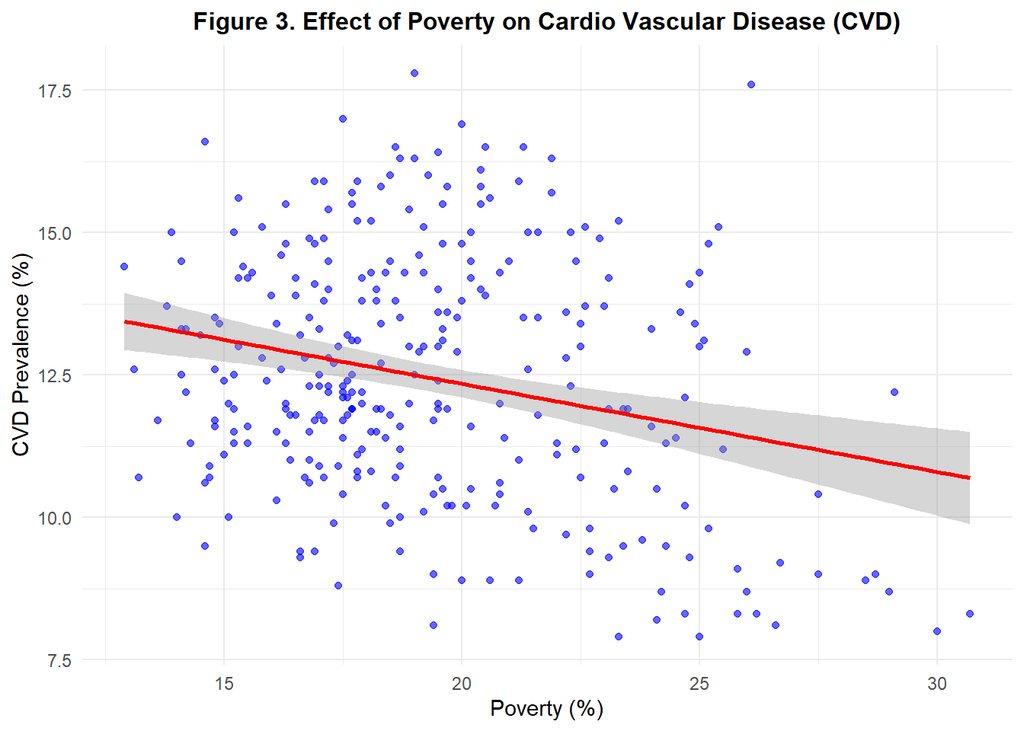

```r
# Fit the linear regression model
# This model predicts cardiovascular disease (CVD) prevalence based on poverty percentage.
lm.cvd.by.poverty <- lm(cvd ~ poverty, data = cleaned_cardio_vasc_data)

# Create a scatter plot with a regression line
plot_poverty <- ggplot(cleaned_cardio_vasc_data, aes(x = poverty, y = cvd)) +
  # Add points to represent data, with blue color and some transparency
  geom_point(color = "blue", alpha = 0.6) +
  # Add a linear regression line with confidence interval shaded
  geom_smooth(method = "lm", color = "red", se = TRUE) +
  # Add labels for the plot, x-axis, and y-axis
  labs(title = "Figure 3. Effect of Poverty on Cardio Vascular Disease (CVD)",
       x = "Poverty (%)",
       y = "CVD Prevalence (%)") +
  # Apply a minimalistic theme for a clean look
  theme_minimal() +
theme(
    plot.title = element_text(hjust = 0.5, size = 12, face = "bold")) # Center-align title

# Print the plot to visualize the relationship
print(plot_poverty)
```

**Interpretation**: In **Figure 3**, the scatterplot with a fitted regression line shows a **negative relationship** between **poverty** and **CVD prevalence**. In simple terms, areas with higher **poverty levels** tend to have slightly lower rates of **CVD**, as seen in the downward slope of the red line. The shaded **confidence interval** shows some variation, but the overall trend is clear.

### *Conclusions*

Our analysis focused on identifying the key factors that influence **CVD prevalence** in a given area, specifically looking at **overweight**, **smoking**, **wellbeing**, and **poverty**.

At the same time, the relationships with **wellbeing** and **poverty** are more complicated. Surprisingly, areas with higher **wellbeing** scores tend to have higher CVD rates, which could be due to factors like **socioeconomic status**, **healthcare access**, or even **reporting biases**. On the other hand, **poverty** seems to lower CVD rates, likely because of **under-reporting** or limited healthcare in poorer areas, where heart disease may not be diagnosed or reported accurately.

## Question 2 - Customer Satisfaction

### *Project Overview*

This analysis aims to examine the factors influencing customer satisfaction within a furniture retail company. The variables under consideration include delivery times, staff job satisfaction, the presence of a new product range, and the socio-economic status (SES) of the store locations. The primary focus is on evaluating the impact of delivery times on customer satisfaction, with particular attention given to whether this effect varies across stores situated in low, medium, and high SES areas by performing the following specific analyses:

1. Provide a data integrity check of the dataset.
2. Provide a data quality check of the dataset.
3. Perform correlation of the dependent variable (`customer_satisfaction`) with each independent variable (`ses_category`, `staff_satisfaction`, `delivery_time`, and `new_range`).
4. Perform multiple linear regression for all independent variables (`ses_category`, `staff_satisfaction`, `delivery_time`, and `new_range`) against the dependent variable (`customer_satisfaction`).
5. Fit an interaction model to examine how (`delivery_time`) and (`ses_category`) interact in predicting (`customer_satisfaction`).
6. Perform NHST (Null Hypothesis Significance Testing) for the regression coefficients of the interaction model.
7. Perform the estimation approach for the interaction model.
8. Calculate the Variance Inflation Factor (VIF) to check for multicollinearity.
9. Perform multicollinearity correction on the predictors using the mean difference method.
10. Perform Null Hypothesis Significance Testing (NHST) on the corrected interaction regression coefficients.
11. Apply the estimation approach to the corrected interaction regression coefficients.
12. Perform ANOVA (Analysis of Variance) to assess the overall significance of the interaction model.
13. Estimate Marginal Means (EMMs) for the interaction terms to assess the adjusted means of (`customer_satisfaction`) across different levels of (`delivery_time`) and (`ses_category`).
14. Fit the interaction model (`customer_satisfaction ~ delivery_time * ses_category`) to examine how (`delivery_time`) and (`ses_category`) interact to affect customer satisfaction.
15. Visualize the interaction effect of (`delivery_time`) and (`ses_category`) on `customer_satisfaction`, showing how the effect varies across different SES levels (e.g., high, medium, low).

### *Data Dictionary*

This customer satisfaction dataset consists of data collected from a furniture retail company, with each row representing one store. The data includes the following variables:

| Variable | Description |
| --- | --- |
| SES_category | The company’s categorization of store type based on local socio-economic status (low, medium, high). |
| customer.satisfaction | The average customer satisfaction score for the store. |
| staff.satisfaction | The average job satisfaction score of the staff at the store. |
| delivery.time | The average delivery time for large and custom items at the store. |
| new_range | Indicates whether the store was carrying a new range of products(FALSE = No, TRUE = Yes). |

### *Read Dataset*

```r
 # Read the customer satisfaction dataset
cust_sat <- read_csv("cust_satisfaction.csv")
# Display the first five rows of the dataset for an overview
head(cust_sat)
```

```
## # A tibble: 6 × 5
##   SES_category customer.satisfaction staff.satisfaction delivery.time new_range
##   <chr>                        <dbl>              <dbl>         <dbl> <lgl>
## 1 Medium                        7.27               6.88          66.7 FALSE
## 2 Medium                        7.93               7.44          68.2 FALSE
## 3 Medium                        7.12               7.15          70.7 FALSE
## 4 High                          6.35               6.47          61.4 TRUE
## 5 High                          6.78               7.06          57.7 TRUE
## 6 Medium                        8.07               7.03          38.0 TRUE
```

### *Data Integrity*

```r
# 1. Display dataset structure
# Use the 'str()' function to review the structure of the dataset, including:
# - Number of observations and variables
# - Variable names, data types, and a preview of their values
str(cust_sat)
```

```
## spc_tbl_ [300 × 5] (S3: spec_tbl_df/tbl_df/tbl/data.frame)
##  $ SES_category         : chr [1:300] "Medium" "Medium" "Medium" "High" ...
##  $ customer.satisfaction: num [1:300] 7.27 7.93 7.12 6.35 6.78 ...
##  $ staff.satisfaction   : num [1:300] 6.88 7.44 7.15 6.47 7.06 ...
##  $ delivery.time        : num [1:300] 66.7 68.2 70.7 61.4 57.7 ...
##  $ new_range            : logi [1:300] FALSE FALSE FALSE TRUE TRUE TRUE ...
##  - attr(*, "spec")=
##   .. cols(
##   ..   SES_category = col_character(),
##   ..   customer.satisfaction = col_double(),
##   ..   staff.satisfaction = col_double(),
##   ..   delivery.time = col_double(),
##   ..   new_range = col_logical()
##   .. )
##  - attr(*, "problems")=<externalptr>
```

```r
# Descriptive statistics for continuous variables
# This provides statistics (e.g., mean, median, min, max) for each variable in the dataset.
summary(cust_sat)
```

```
##  SES_category       customer.satisfaction staff.satisfaction delivery.time   new_range
##  Length:300         Min.   :3.760         Min.   :4.850      Min.   :32.96   Mode :logical
##  Class :character   1st Qu.:6.099         1st Qu.:6.216      1st Qu.:52.46   FALSE:142
##  Mode  :character   Median :7.006         Median :6.634      Median :60.45   TRUE :158
##                     Mean   :6.930         Mean   :6.751      Mean   :59.60
##                     3rd Qu.:7.865         3rd Qu.:7.274      3rd Qu.:66.79
##                     Max.   :9.670         Max.   :8.860      Max.   :92.48
```

```r
# 2. Standardize column names
# Ensure consistency in column naming by:
# - Replacing periods (".") with underscores ("_")
# - Converting all characters to lowercase
colnames(cust_sat) <- tolower(gsub("\\.", "_", colnames(cust_sat)))

# Print updated column names for verification
print(colnames(cust_sat))
```

```
## [1] "ses_category"          "customer_satisfaction" "staff_satisfaction"    "delivery_time"
## [5] "new_range"
```

```r
# 4. Format character columns
character_columns <- names(cust_sat)[sapply(cust_sat, is.character)]
print(character_columns) # Displays all character columns in the dataset
```

```
## [1] "ses_category"
```

```r
# 5. Format numeric columns
# Define columns expected to contain numeric data
numeric_columns <- c("customer_satisfaction", "staff_satisfaction", "delivery_time")

# Check if specific columns are numeric
sapply(cust_sat[numeric_columns], is.numeric) #This will return TRUE for columns that are numeric and FALSE for columns that are not.
```

```
## customer_satisfaction    staff_satisfaction         delivery_time
##                  TRUE                  TRUE                  TRUE
```

```r
# 6.Check for unique values in categorical column(ses_category)
unique(cust_sat$ses_category)
```

```
## [1] "Medium" "High"   "Low"
```

```r
# 7.Validate categorical values in 'ses_category' column
# Define the unique values present in 'ses_category' column for valid categories
# Check if all values in the column belong to the valid categories
valid_categories <- c(unique(cust_sat$ses_category))
ses_category_is_categorical <- all(cust_sat$ses_category %in% valid_categories)

# Print the result: TRUE if all values are valid, FALSE otherwise
print(ses_category_is_categorical)
```

```
## [1] TRUE
```

```r
# 8.Validate the 'new_range' column for boolean values
# Ensure that the 'new_range' column contains only boolean values (TRUE or FALSE)
new_range_col_valid_values <- all(is.logical(cust_sat$new_range))

# Print the result: TRUE if the column contains only boolean values, FALSE otherwise
print(new_range_col_valid_values)
```

```
## [1] TRUE
```

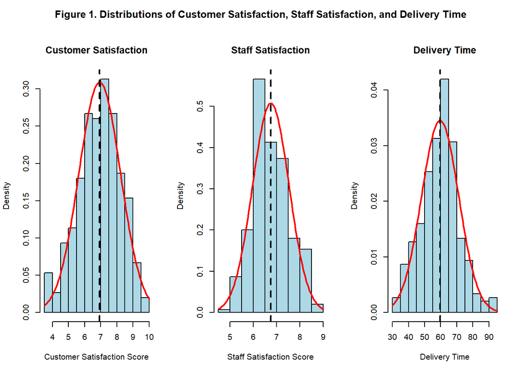

```r
#9. Visualize the normal distribution of the numeric columns (staff_satisfaction, delivery_time, customer_satisfaction)

# Set layout for 3 plots side by side
par(mfrow = c(1, 3), oma = c(0, 0, 3, 0))  # Add outer margin space for the title

# Histogram and normal curve for customer satisfaction
hist(cust_sat$customer_satisfaction,
     main = "Customer Satisfaction",
     col = "lightblue",
     xlab = "Customer Satisfaction Score",
     probability = TRUE)
curve(dnorm(x, mean = mean(cust_sat$customer_satisfaction),
              sd = sd(cust_sat$customer_satisfaction)),
      col = "red", lwd = 2, add = TRUE)
abline(v = mean(cust_sat$customer_satisfaction), col = "black", lwd = 2, lty = 2)  # Mean line

# Histogram and normal curve for staff satisfaction
hist(cust_sat$staff_satisfaction,
     main = "Staff Satisfaction",
     col = "lightblue",
     xlab = "Staff Satisfaction Score",
     probability = TRUE)
curve(dnorm(x, mean = mean(cust_sat$staff_satisfaction),
              sd = sd(cust_sat$staff_satisfaction)),
      col = "red", lwd = 2, add = TRUE)
abline(v = mean(cust_sat$staff_satisfaction), col = "black", lwd = 2, lty = 2)  # Mean line

# Histogram and normal curve for delivery time
hist(cust_sat$delivery_time,
     main = "Delivery Time",
     col = "lightblue",
     xlab = "Delivery Time",
     probability = TRUE)
curve(dnorm(x, mean = mean(cust_sat$delivery_time),
              sd = sd(cust_sat$delivery_time)),
      col = "red", lwd = 2, add = TRUE)
abline(v = mean(cust_sat$delivery_time), col = "black", lwd = 2, lty = 2)  # Mean line

# Add an overarching title
mtext("Figure 1. Distributions of Customer Satisfaction, Staff Satisfaction, and Delivery Time",
      side = 3, line = 1, outer = TRUE, font = 2, cex = 0.80)
```

```r
# Reset layout to default
par(mfrow = c(1, 1))
```

**Interpretation:** Figure 1, shows that **`customer_satisfaction`** and **`staff_satisfaction`** **exhibit minimal skewness, with symmetric density curves centered around the mean, resembling a normal distribution**.

However, **`delivery_time`** displays **slight positive skewness**, with a **longer right tail caused by a few higher values. While this skewness doesn’t significantly impact interpretation, it highlights variability and occasional delays**.

Addressing this can reveal **operational inefficiencies without distorting overall trends**.

### *Data Cleaning*

```r
#1. Check for missing values
# Count the number of missing (NA) values in each column
missing_count <- colSums(is.na(cust_sat))

# Print the count of missing values for each column
print(missing_count)
```

```
##          ses_category customer_satisfaction    staff_satisfaction         delivery_time
##                     0                     0                     0                     0
##             new_range
##                     0
```

```r
#2. Identify duplicate rows
# Check for duplicate rows, considering both forward and reverse orders
duplicates <- cust_sat %>% filter(duplicated(.) | duplicated(., fromLast = TRUE))

# Display any duplicate rows if found.
print(duplicates)
```

```
## # A tibble: 0 × 5
## # ℹ 5 variables: ses_category <chr>, customer_satisfaction <dbl>, staff_satisfaction <dbl>,
## #   delivery_time <dbl>, new_range <lgl>
```

```r
#3. Remove leading and trailing whitespaces from character columns
cust_sat[character_columns] <- lapply(cust_sat[character_columns], trimws)
print(cust_sat[character_columns])
```

```
## # A tibble: 300 × 1
##    ses_category
##    <chr>
##  1 Medium
##  2 Medium
##  3 Medium
##  4 High
##  5 High
##  6 Medium
##  7 Medium
##  8 Medium
##  9 Medium
## 10 High
## # ℹ 290 more rows
```

```r
#4. Convert categorical column(ses_category) to factor(ses_category_factor)

cust_sat$ses_category_factor<- factor(cust_sat$ses_category,
                                  levels = c("Low", "Medium", "High"))

print(cust_sat$ses_category_factor)
```

```
##   [1] Medium Medium Medium High   High   Medium Medium Medium Medium High   Low    High   High
##  [14] Low    High   Low    High   Medium Low    Low    High   Medium High   High   High   Low
##  [27] Medium Low    High   Low    Low    Medium Medium Low    Medium High   Low    Low    High
##  [40] Low    Low    Medium High   High   High   Medium High   Medium High   Medium Low    Low
##  [53] High   Medium High   Low    Medium High   High   Low    Low    Low    Medium Medium High
##  [66] Medium High   High   Medium High   High   Medium Low    Medium Medium Low    Low    Low
##  [79] High   Medium High   High   Medium Low    Low    High   Medium High   Low    Low    Medium
##  [92] Medium Low    Medium Low    Low    Low    High   Low    Low    Low    Medium High   Low
## [105] Low    High   Low    High   Low    Medium High   High   Medium High   Medium Low    Low
## [118] Low    Medium Medium Low    Medium High   Low    High   High   Medium High   Medium High
## [131] Low    Medium High   Low    High   Low    Medium High   High   High   Low    High   High
## [144] High   Low    High   Low    High   Low    Low    High   High   High   Low    Medium Medium
## [157] Low    Low    Low    High   Medium High   High   Low    Medium High   Medium High   Medium
## [170] Medium High   Medium Low    Low    High   High   Low    Medium Medium Medium High   Medium
## [183] Medium High   High   Medium Low    Medium Medium Low    High   Medium Low    Low    Medium
## [196] Low    Medium Medium High   Medium Medium Medium High   Medium Low    Low    Low    Low
## [209] Low    Low    High   Medium Medium Medium High   Low    Medium High   Medium Medium High
## [222] High   High   Medium Low    Low    Medium Medium Medium Medium Medium High   Low    Low
## [235] High   Low    Medium Low    High   Medium Medium Low    Low    Low    Medium Medium High
## [248] High   Low    Low    Low    Low    High   Low    High   Low    High   Medium Medium Medium
## [261] High   Low    Medium Medium Low    High   Low    Low    High   Medium Medium Low    Medium
## [274] Medium High   Medium High   Low    High   Low    Low    Low    High   High   High   Medium
## [287] Medium High   Medium Low    High   Low    High   Low    Medium Medium Low    High   Medium
## [300] High
## Levels: Low Medium High
```

```r
#5. Convert logical vector(new_range) to numeric(new_range_numeric)
cust_sat$new_range_numeric <- as.numeric(cust_sat$new_range)

# Verify the update
print(cust_sat$new_range_numeric)
```

```
##   [1] 0 0 0 1 1 1 1 0 0 1 0 0 0 1 0 1 0 1 1 1 1 1 1 1 0 1 0 1 1 0 0 1 1 0 1 0 0 1 1 0 1 1 1 0 0 1 1
##  [48] 0 0 0 0 1 0 1 0 0 0 1 0 0 1 1 0 1 0 0 0 1 1 1 0 1 0 1 0 1 0 1 1 1 0 1 0 0 0 0 1 0 1 0 1 0 0 0
##  [95] 1 1 0 1 1 1 1 1 0 1 0 1 1 1 0 0 1 1 0 0 1 1 0 0 0 1 1 0 1 0 1 1 0 1 1 0 1 0 0 0 1 1 1 0 1 0 1
## [142] 0 1 1 0 0 1 0 1 0 0 1 1 1 1 0 0 1 0 0 1 1 0 0 1 1 1 0 1 1 1 0 0 0 0 1 0 0 1 0 0 1 1 1 1 1 0 1
## [189] 1 1 0 0 0 0 1 0 0 1 0 1 1 0 0 0 1 1 0 1 1 1 1 1 1 1 1 1 1 1 1 0 0 1 0 1 1 0 0 0 1 1 1 0 1 0 1
## [236] 1 0 0 1 1 1 1 0 1 1 0 1 0 0 1 1 0 1 1 0 1 1 0 0 0 0 1 0 0 1 1 0 1 0 1 0 1 0 0 0 0 0 0 0 0 0 1
## [283] 1 0 1 0 1 1 1 1 1 1 0 0 0 0 1 1 0 0
```

```r
#6. Round numeric columns
# Round specific numeric columns to two decimal places for precision and readability
cust_sat[, numeric_columns] <- lapply(cust_sat[, numeric_columns], round, 2)

# Print the updated data frame to review changes
print(cust_sat)
```

```
## # A tibble: 300 × 7
##    ses_category customer_satisfaction staff_satisfaction delivery_time new_range ses_category_factor
##    <chr>                        <dbl>              <dbl>         <dbl> <lgl>     <fct>
##  1 Medium                        7.27               6.88          66.7 FALSE     Medium
##  2 Medium                        7.93               7.44          68.2 FALSE     Medium
##  3 Medium                        7.12               7.15          70.7 FALSE     Medium
##  4 High                          6.35               6.47          61.4 TRUE      High
##  5 High                          6.78               7.06          57.7 TRUE      High
##  6 Medium                        8.07               7.03          38.0 TRUE      Medium
##  7 Medium                        9                  7.35          52.8 TRUE      Medium
##  8 Medium                        7.53               7.77          68.8 FALSE     Medium
##  9 Medium                        7.42               7.52          79.6 FALSE     Medium
## 10 High                          7.45               6.56          57.7 TRUE      High
## # ℹ 290 more rows
## # ℹ 1 more variable: new_range_numeric <dbl>
```

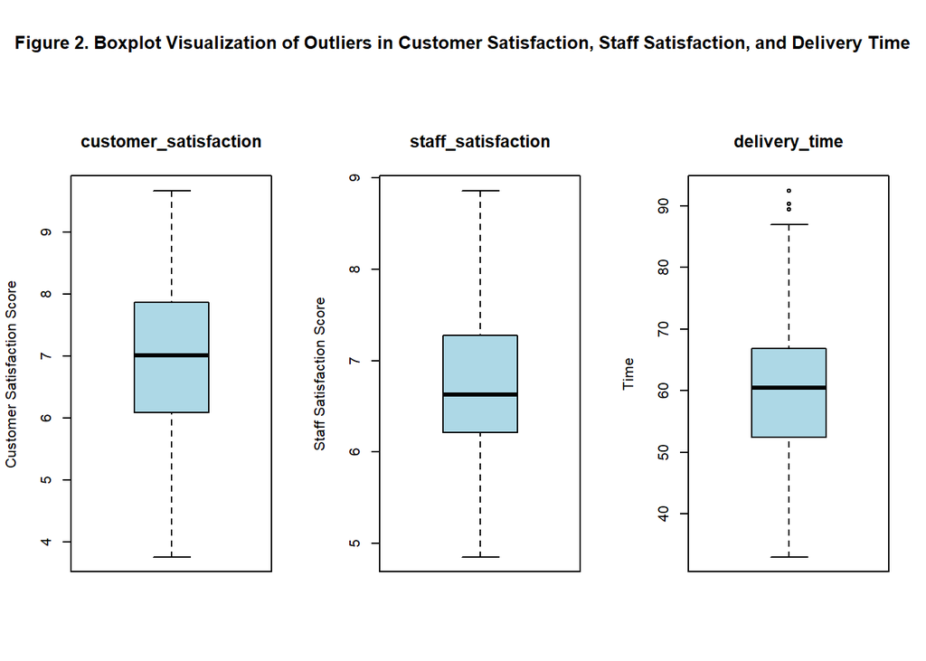

```r
#7.Detect and review outliers

# Adjust layout for multiple boxplots
par(mfrow = c(1, length(numeric_columns)))

par(oma = c(0, 0, 6, 0))  # Allocate enough space for the top margin

# Specify the three columns to generate boxplots for
selected_columns <- c("customer_satisfaction", "staff_satisfaction", "delivery_time")

# Define custom y-axis labels for each of the selected columns
y_labels <- c(
  "customer_satisfaction" = "Customer Satisfaction Score",
  "staff_satisfaction" = "Staff Satisfaction Score",
  "delivery_time" = "Time"
)

# Loop through each selected column and generate a separate boxplot with its own title and y-axis label
for (col in selected_columns) {
  # Generate a boxplot for each selected column
  boxplot(cust_sat[[col]],
          main = col,             # Column name as title
          col = "lightblue",      # Set the color of the box
          xlab = "",              # Remove the x-axis label
          ylab = y_labels[[col]], # Custom Y-axis label
          xaxt = "n"              # Suppress the x-axis
  )
}


# Add a main title for the entire grid of plots
mtext("Figure 2. Boxplot Visualization of Outliers in Customer Satisfaction, Staff Satisfaction, and Delivery Time",
      outer = TRUE, line = 3, cex = 0.82, font = 2)
```

**Interpretation:** The boxplots in Figure 2, show **no outliers** for **`customer_satisfaction`** and **`staff_satisfaction`**, indicating **consistent and reliable responses**.

However, **`delivery_time`** reveals **three outliers** above **90**, reflecting **real-world delays**. These outliers were retained as they indicate a **slight positive skewness** in the data, highlighting **variability** in delivery performance.

**Removing them would artificially reduce the skewness and distort the true representation of the delivery system’s variability and potential inefficiencies, which are critical for identifying and addressing operational issues.**

### *Correlation Analysis*

```r
cust_sat$ses_category_numeric = as.numeric(cust_sat$ses_category_factor)

# Define the continuous numeric columns to analyze
numeric_columns <- c("ses_category_numeric", "customer_satisfaction", "staff_satisfaction", "delivery_time", "new_range_numeric")

# Compute and display the pearson correlation matrix
pearson_corr_matrix <- cor(cust_sat[, numeric_columns], method = "pearson")

print("Pearson Correlation Coefficients:")
```

```
## [1] "Pearson Correlation Coefficients:"
```

```r
print(pearson_corr_matrix)
```

```
##                       ses_category_numeric customer_satisfaction staff_satisfaction delivery_time
## ses_category_numeric            1.00000000            0.11524696         0.09281944   -0.09929250
## customer_satisfaction           0.11524696            1.00000000         0.45399054   -0.25885366
## staff_satisfaction              0.09281944            0.45399054         1.00000000   -0.06505203
## delivery_time                  -0.09929250           -0.25885366        -0.06505203    1.00000000
## new_range_numeric              -0.02452981            0.05024752         0.03057617   -0.04605689
##                       new_range_numeric
## ses_category_numeric        -0.02452981
## customer_satisfaction        0.05024752
## staff_satisfaction           0.03057617
## delivery_time               -0.04605689
## new_range_numeric            1.00000000
```

**Interpretation:** The **pearson correlation matrix** reveals key insights:

The analysis highlights the following key findings:

- **Staff satisfaction** and **customer satisfaction** are moderately positively correlated (**r = 0.454**), meaning that when employees are happier, customers tend to be more satisfied as well.
- **Delivery time** shows a weak negative correlation with customer satisfaction (**r = -0.259**), indicating that longer delivery times slightly reduce satisfaction.
- The relationship between **SES category** and customer satisfaction is weakly positive (**r = 0.115**), suggesting a minor connection, but it doesn’t appear to have a strong impact.
- **New range** has negligible correlations with customer satisfaction, meaning it has little effect on customer satisfaction levels.

In summary, **staff satisfaction** is the most important factor influencing **customer satisfaction**, with **delivery time** and **SES category** having a more limited impact.

### *Multiple Linear Regression*

```r
# Multiple linear regression model
# This models the relationship between customer satisfaction and the predictors: staff satisfaction, delivery time, new range, and SES category
multiple_regression_model <- lm(customer_satisfaction ~ staff_satisfaction + delivery_time + new_range_numeric + ses_category, data = cust_sat)

# Display the summary of the model
# The summary provides coefficients, p-values, and R-squared to evaluate the model
model_summary <- summary(multiple_regression_model)
print(model_summary)
```

```
##
## Call:
## lm(formula = customer_satisfaction ~ staff_satisfaction + delivery_time +
##     new_range_numeric + ses_category, data = cust_sat)
##
## Residuals:
##     Min      1Q  Median      3Q     Max
## -2.5984 -0.6833 -0.0124  0.6542  2.8926
##
## Coefficients:
##                     Estimate Std. Error t value Pr(>|t|)
## (Intercept)         5.221734   0.610230   8.557 6.52e-16 ***
## staff_satisfaction  0.350659   0.080450   4.359 1.81e-05 ***
## delivery_time      -0.017219   0.004948  -3.480 0.000578 ***
## new_range_numeric   0.093754   0.112254   0.835 0.404286
## ses_categoryLow    -0.255904   0.138547  -1.847 0.065745 .
## ses_categoryMedium  1.209184   0.147795   8.181 8.55e-15 ***
## ---
## Signif. codes:  0 '***' 0.001 '**' 0.01 '*' 0.05 '.' 0.1 ' ' 1
##
## Residual standard error: 0.9687 on 294 degrees of freedom
## Multiple R-squared:  0.4469, Adjusted R-squared:  0.4375
## F-statistic: 47.51 on 5 and 294 DF,  p-value: < 2.2e-16
```

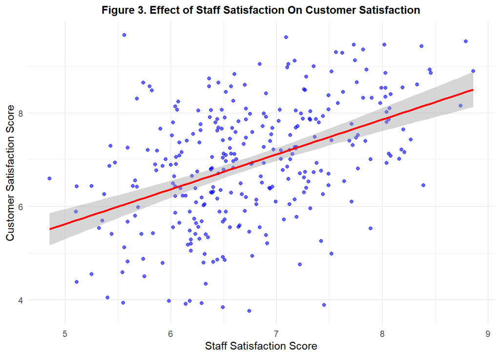

```r
# Visualization: Scatter plot for Customer Satisfaction vs Staff Satisfaction
# Shows the relationship between staff satisfaction and customer satisfaction with a linear regression line
ggplot(cust_sat, aes(x = staff_satisfaction, y = customer_satisfaction)) +
  geom_point(color = "blue", alpha = 0.6) +  # Scatter points
  geom_smooth(method = "lm", color = "red", se = TRUE) +  # Regression line with confidence interval
  labs(title = "Figure 3. Effect of Staff Satisfaction On Customer Satisfaction",
       x = "Staff Satisfaction Score",
       y = "Customer Satisfaction Score") +
  theme_minimal() +
  theme(plot.title = element_text(size = 11, face = "bold", hjust = 0.5))  # Bold title
```

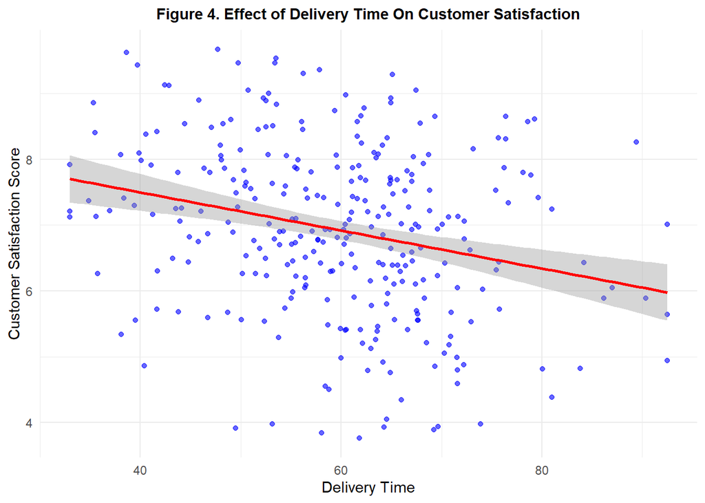

```r
# Visualization: Scatter plot for Customer Satisfaction vs Delivery Time
# Illustrates the effect of delivery time on customer satisfaction with a linear regression line
ggplot(cust_sat, aes(x = delivery_time, y = customer_satisfaction)) +
  geom_point(color = "blue", alpha = 0.6) +  # Scatter points
  geom_smooth(method = "lm", color = "red", se = TRUE) +  # Regression line with confidence interval
  labs(title = "Figure 4. Effect of Delivery Time On Customer Satisfaction",
       x = "Delivery Time",
       y = "Customer Satisfaction Score") +
  theme_minimal() +
  theme(plot.title = element_text(size = 11, face = "bold", hjust = 0.5))  # Bold title
```

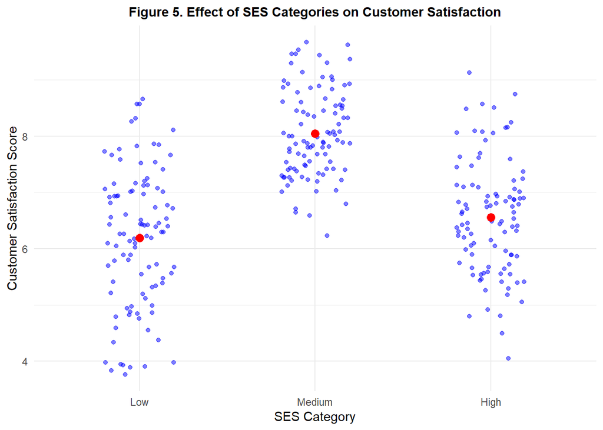

```r
# Visualization: Scatter plot with mean points and error bars for SES categories
# Shows the distribution of customer satisfaction for each SES category with mean points and confidence intervals
ggplot(cust_sat, aes(x = ses_category_factor, y = customer_satisfaction)) +
  geom_jitter(color = "blue", alpha = 0.5, width = 0.2) +  # Scatter points with jitter to avoid overlap
  stat_summary(fun = mean, geom = "point", color = "red", size = 3) +  # Mean points
  stat_summary(fun.data = mean_cl_normal, geom = "errorbar", width = 0.2, color = "red") +  # Error bars for confidence intervals
  labs(title = "Figure 5. Effect of SES Categories on Customer Satisfaction",
       x = "SES Category", y = "Customer Satisfaction Score") +
  theme_minimal() +
  theme(plot.title = element_text(size = 11, face = "bold", hjust = 0.5))  # Bold title
```

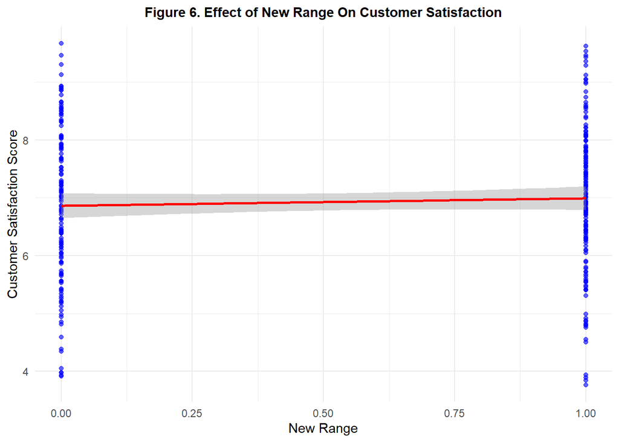

```r
# Visualization: Scatter plot for Customer Satisfaction vs New Range
# Shows the relationship between new range and customer satisfaction with a linear regression line
ggplot(cust_sat, aes(x = new_range_numeric, y = customer_satisfaction)) +
  geom_point(color = "blue", alpha = 0.6) +  # Scatter points
  geom_smooth(method = "lm", color = "red", se = TRUE) +  # Regression line with confidence interval
  labs(title = "Figure 6. Effect of New Range On Customer Satisfaction",
       x = "New Range",
       y = "Customer Satisfaction Score") +
  theme_minimal() +
  theme(plot.title = element_text(size = 11, face = "bold", hjust = 0.5)) # Bold title
```

**Interpretation:** The multiple linear regression model provides valuable insights into the drivers of **customer satisfaction**. It reveals that **staff satisfaction** (p = 1.81e-05) is a major factor—happier employees lead to happier customers. On the other hand, **delivery time** (p = 0.000578) has a strong negative effect, with longer waits significantly hurting satisfaction. Customers in **medium SES areas** see a significant boost in satisfaction (1.209, p = 8.55e-15), while those in **low SES areas** show a small negative trend (-0.256, p = 0.065745). Interestingly, **new product ranges** don’t seem to have much impact (p = 0.404286). The model explains **44.7%** of the variation in satisfaction (R-squared = 0.447) and is highly statistically significant (F = 47.51, p < 2.2e-16), proving its robustness.

In conclusion, the findings suggest that businesses should focus on **staff engagement**, eliminate **delivery inefficiencies**, and create **targeted solutions** for different customer segments to improve satisfaction.

### *Interaction Model*

```r
# Multiple linear regression with interaction term
model_interaction <- lm(customer_satisfaction ~ delivery_time * ses_category_factor, data = cust_sat)

# Summary of the model
summary(model_interaction)
```

```
##
## Call:
## lm(formula = customer_satisfaction ~ delivery_time * ses_category_factor,
##     data = cust_sat)
##
## Residuals:
##     Min      1Q  Median      3Q     Max
## -2.4331 -0.6265  0.0026  0.7221  2.5295
##
## Coefficients:
##                                          Estimate Std. Error t value Pr(>|t|)
## (Intercept)                              6.502056   0.522299  12.449  < 2e-16 ***
## delivery_time                           -0.004996   0.008224  -0.608  0.54395
## ses_category_factorMedium                2.411906   0.727356   3.316  0.00103 **
## ses_category_factorHigh                  2.118142   0.774586   2.735  0.00663 **
## delivery_time:ses_category_factorMedium -0.010277   0.011991  -0.857  0.39211
## delivery_time:ses_category_factorHigh   -0.029692   0.012535  -2.369  0.01849 *
## ---
## Signif. codes:  0 '***' 0.001 '**' 0.01 '*' 0.05 '.' 0.1 ' ' 1
##
## Residual standard error: 0.9916 on 294 degrees of freedom
## Multiple R-squared:  0.4205, Adjusted R-squared:  0.4106
## F-statistic: 42.66 on 5 and 294 DF,  p-value: < 2.2e-16
```

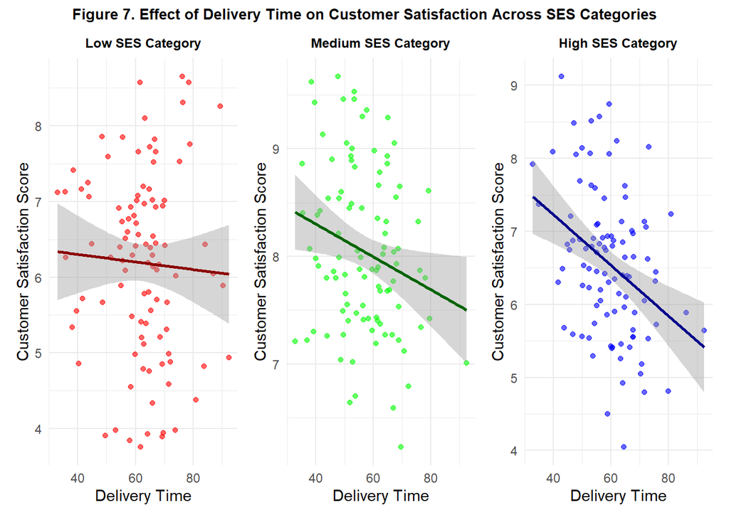

```r
# Visualization: Interaction plot

# Create individual plots for each SES category
plot_low <- ggplot(cust_sat %>% filter(ses_category_factor == "Low"),
                   aes(x = delivery_time, y = customer_satisfaction)) +
  geom_point(color = "red", alpha = 0.6) +
  geom_smooth(method = "lm", color = "darkred", se = TRUE) +
  labs(title = "Low SES Category",
       x = "Delivery Time",
       y = "Customer Satisfaction Score") +
  theme_minimal() +
  theme(plot.title = element_text(face = "bold", hjust = 0.5, size = 9))

plot_medium <- ggplot(cust_sat %>% filter(ses_category_factor == "Medium"),
                      aes(x = delivery_time, y = customer_satisfaction)) +
  geom_point(color = "green", alpha = 0.6) +
  geom_smooth(method = "lm", color = "darkgreen", se = TRUE) +
  labs(title = "Medium SES Category",
       x = "Delivery Time",
       y = "Customer Satisfaction Score") +
  theme_minimal() +
  theme(plot.title = element_text(face = "bold", hjust = 0.5, size = 9))

plot_high <- ggplot(cust_sat %>% filter(ses_category_factor == "High"),
                    aes(x = delivery_time, y = customer_satisfaction)) +
  geom_point(color = "blue", alpha = 0.6) +
  geom_smooth(method = "lm", color = "darkblue", se = TRUE) +
  labs(title = "High SES Category",
       x = "Delivery Time",
       y = "Customer Satisfaction Score") +
  theme_minimal() +
  theme(plot.title = element_text(face = "bold", hjust = 0.5 , size = 9))

# Combine the plots into a grid layout
(plot_low | plot_medium | plot_high) +
  plot_annotation(title = "Figure 7. Effect of Delivery Time on Customer Satisfaction Across SES Categories",
                  theme = theme(plot.title = element_text(face = "bold", hjust = 0.5 , size = 10)))
```

**Interpretation:** Figure 7 highlights how **delivery time** influences **customer satisfaction** across different **SES groups**.

- **High SES** customers are highly sensitive to delays (**p = 0.018**), meaning they expect faster service for a positive experience.
- **Medium SES** customers show a moderate, but **non-significant** trend (**p = 0.392**), suggesting that while delivery time affects them, it’s not as impactful.
- **Low SES** customers seem less concerned with delivery speed, likely prioritizing **affordability** over quick delivery.

With an **adjusted R-squared** of **0.41**, the model indicates that **SES** significantly influences how delivery time impacts satisfaction. This suggests that **high SES** customers need faster delivery, while other groups might value cost or other factors more.

### *Null Hypothesis Significant Testing: Interaction Model Regression Coefficients*

```r
# Display the summary of the interaction model
# Provides coefficients, p-values, and R-squared to evaluate the significance and impact of each predictor.
summary(model_interaction)
```

```
##
## Call:
## lm(formula = customer_satisfaction ~ delivery_time * ses_category_factor,
##     data = cust_sat)
##
## Residuals:
##     Min      1Q  Median      3Q     Max
## -2.4331 -0.6265  0.0026  0.7221  2.5295
##
## Coefficients:
##                                          Estimate Std. Error t value Pr(>|t|)
## (Intercept)                              6.502056   0.522299  12.449  < 2e-16 ***
## delivery_time                           -0.004996   0.008224  -0.608  0.54395
## ses_category_factorMedium                2.411906   0.727356   3.316  0.00103 **
## ses_category_factorHigh                  2.118142   0.774586   2.735  0.00663 **
## delivery_time:ses_category_factorMedium -0.010277   0.011991  -0.857  0.39211
## delivery_time:ses_category_factorHigh   -0.029692   0.012535  -2.369  0.01849 *
## ---
## Signif. codes:  0 '***' 0.001 '**' 0.01 '*' 0.05 '.' 0.1 ' ' 1
##
## Residual standard error: 0.9916 on 294 degrees of freedom
## Multiple R-squared:  0.4205, Adjusted R-squared:  0.4106
## F-statistic: 42.66 on 5 and 294 DF,  p-value: < 2.2e-16
```

**Interpretation:** The interaction model identifies key predictors of **customer satisfaction**.

**Medium SES** increases satisfaction by **2.41 units** (**p = 0.001**), and **High SES** increases it by **2.12 units** (**p = 0.007**).

**Delivery time** alone has no significant effect (**p = 0.544**), but its interaction with **High SES** significantly reduces satisfaction by **0.03 units per unit increase** (**p = 0.018**).

The **interaction with Medium SES** is not significant (**p = 0.392**). The model explains **42%** of the variance in satisfaction (**Adjusted R² = 0.41**).

### *Estimation Approach: Interaction Model Regression Coefficients*

```r
# Extract coefficients and confidence intervals
estimation_results <- tidy(model_interaction, conf.int = TRUE)

# Rename columns for clarity
colnames(estimation_results) <- c("Predictor", "Coefficient", "Std.Error", "Statistic", "P-value", "95% CI Lower", "95% CI Upper")

# Select relevant columns for display
estimation_results <- estimation_results[, c("Predictor", "Coefficient", "95% CI Lower", "95% CI Upper")]

kable_table <- estimation_results %>%
  kable("html", digits = 3, col.names = c("Variable", "Estimate", "Lower 95% CI", "Upper 95% CI"), caption = "<span style='font-size:13px;font-weight:bold; color:black';>Figure 8. Coefficients and 95% Confidence Intervals</span>") %>%
  kable_styling(
    bootstrap_options = c("striped", "hover", "condensed", "responsive"),
    full_width = FALSE,
    font_size = 12,
    position = "center",
    latex_options = "HOLD_position"
  ) %>%
  column_spec(1, bold = TRUE) %>% # Make the first column bold
  row_spec(0, bold = TRUE, background = "#D3D3D3") # Bold header row with background color

# Display the table
kable_table
```

Figure 8. Coefficients and 95% Confidence Intervals

| Variable | Estimate | Lower 95% CI | Upper 95% CI |
| --- | --- | --- | --- |
| (Intercept) | 6.502 | 5.474 | 7.530 |
| delivery_time | -0.005 | -0.021 | 0.011 |
| ses_category_factorMedium | 2.412 | 0.980 | 3.843 |
| ses_category_factorHigh | 2.118 | 0.594 | 3.643 |
| delivery_time:ses_category_factorMedium | -0.010 | -0.034 | 0.013 |
| delivery_time:ses_category_factorHigh | -0.030 | -0.054 | -0.005 |

**Interpretation:** **Figure 8** reveals that while **`delivery_time`** alone (**-0.005**, **95% CI: [-0.021, 0.011]**) does not significantly affect satisfaction, its **interaction** with **high SES** areas (**-0.030**, **95% CI: [-0.054, -0.005]**) shows that **longer delivery times significantly reduce satisfaction**, reflecting **higher expectations** in these areas.

Being in **medium SES** (**2.412**, **95% CI: [0.980, 3.843]**) or **high SES** (**2.118**, **95% CI: [0.594, 3.643]**) **increases satisfaction**, highlighting the **greater needs** of these customers.

These results emphasize the **importance of fast delivery**, especially in **high SES locations**, to meet expectations and avoid dissatisfaction.

### *Variance Inflation Factor (VIF): Detecting Multicollinearity*

```r
# Calculate Variance Inflation Factor (VIF) for the predictors in the interaction model
vif <- vif(model_interaction)
```

```
## there are higher-order terms (interactions) in this model
## consider setting type = 'predictor'; see ?vif
```

```r
# Display the VIF values for each predictor
cat("Variance Inflation Factor (VIF) for CVD Predictors:\n")
```

```
## Variance Inflation Factor (VIF) for CVD Predictors:
```

```r
print(vif)
```

```
##                                         GVIF Df GVIF^(1/(2*Df))
## delivery_time                       2.746761  1        1.657335
## ses_category_factor               837.929343  2        5.380242
## delivery_time:ses_category_factor 816.676837  2        5.345798
```

**Interpretation:** The **VIF** analysis reveals potential **multicollinearity** issues, particularly with the **interaction term** and **`ses_category`**.

While the **VIF for `delivery_time`** is **1.66**, indicating low multicollinearity, the **VIF for `ses_category_factor`** (**5.38**) and the **interaction term** (**5.35**) **are concerning. These high values suggest a strong correlation between these predictors, which could inflate standard errors and affect model reliability**.

**Simplifying predictors or reconsidering the interaction term** could help **mitigate these multicollinearity** concerns.

### *Multicollinearity Correction*

```r
#Fixing the multicollinearity using centering
# Center the 'delivery_time' variable
cust_sat$center_delivery_time <- cust_sat$delivery_time - mean(cust_sat$delivery_time)

# Perform a regression with the centered variable
corrected_model <- lm(customer_satisfaction ~ center_delivery_time + ses_category_factor + staff_satisfaction + new_range_numeric, data = cust_sat)

# View the regression summary
summary(corrected_model)
```

```
##
## Call:
## lm(formula = customer_satisfaction ~ center_delivery_time + ses_category_factor +
##     staff_satisfaction + new_range_numeric, data = cust_sat)
##
## Residuals:
##     Min      1Q  Median      3Q     Max
## -2.5984 -0.6833 -0.0124  0.6542  2.8926
##
## Coefficients:
##                            Estimate Std. Error t value Pr(>|t|)
## (Intercept)                3.939633   0.526002   7.490 8.11e-13 ***
## center_delivery_time      -0.017219   0.004948  -3.480 0.000578 ***
## ses_category_factorMedium  1.465089   0.155625   9.414  < 2e-16 ***
## ses_category_factorHigh    0.255904   0.138547   1.847 0.065745 .
## staff_satisfaction         0.350659   0.080450   4.359 1.81e-05 ***
## new_range_numeric          0.093754   0.112254   0.835 0.404286
## ---
## Signif. codes:  0 '***' 0.001 '**' 0.01 '*' 0.05 '.' 0.1 ' ' 1
##
## Residual standard error: 0.9687 on 294 degrees of freedom
## Multiple R-squared:  0.4469, Adjusted R-squared:  0.4375
## F-statistic: 47.51 on 5 and 294 DF,  p-value: < 2.2e-16
```

```r
corrected_vif <- vif(corrected_model)

# Display the VIF values for each predictor
cat("Corrected Variance Inflation Factor (VIF) for CVD Predictors:\n")
```

```
## Corrected Variance Inflation Factor (VIF) for CVD Predictors:
```

```r
print(corrected_vif)
```

```
##                          GVIF Df GVIF^(1/(2*Df))
## center_delivery_time 1.041968  1        1.020768
## ses_category_factor  1.319544  2        1.071781
## staff_satisfaction   1.275408  1        1.129340
## new_range_numeric    1.004285  1        1.002140
```

**Interpretation:** By **centering the `delivery_time`** variable, **multicollinearity** was reduced, with **VIF values** between **1.004 and 1.320**, well below 5.

The regression shows that **`delivery_time`** significantly impacts customer satisfaction (p = 0.000578), with **faster delivery** improving satisfaction.

**Medium SES** is a major factor (p < 2e-16), and **staff satisfaction** also plays a key role (p = 1.81e-05). The effect of **high SES** is marginally significant (p = 0.0657), while **`new_range_numeric`** has no significant influence (p = 0.404).

The model addresses multicollinearity and provides **clear, reliable insights**.

### *Null Hypothesis Significance Testing: Corrected Interaction Model Regression Coefficients*

```r
summary(corrected_model)
```

```
##
## Call:
## lm(formula = customer_satisfaction ~ center_delivery_time + ses_category_factor +
##     staff_satisfaction + new_range_numeric, data = cust_sat)
##
## Residuals:
##     Min      1Q  Median      3Q     Max
## -2.5984 -0.6833 -0.0124  0.6542  2.8926
##
## Coefficients:
##                            Estimate Std. Error t value Pr(>|t|)
## (Intercept)                3.939633   0.526002   7.490 8.11e-13 ***
## center_delivery_time      -0.017219   0.004948  -3.480 0.000578 ***
## ses_category_factorMedium  1.465089   0.155625   9.414  < 2e-16 ***
## ses_category_factorHigh    0.255904   0.138547   1.847 0.065745 .
## staff_satisfaction         0.350659   0.080450   4.359 1.81e-05 ***
## new_range_numeric          0.093754   0.112254   0.835 0.404286
## ---
## Signif. codes:  0 '***' 0.001 '**' 0.01 '*' 0.05 '.' 0.1 ' ' 1
##
## Residual standard error: 0.9687 on 294 degrees of freedom
## Multiple R-squared:  0.4469, Adjusted R-squared:  0.4375
## F-statistic: 47.51 on 5 and 294 DF,  p-value: < 2.2e-16
```

**Interpretation:** The corrected model shows that each unit increase in **centered delivery time decreases satisfaction** by **0.017 units** (**p < 0.001**).

**Medium SES boosts satisfaction by** **1.47 units** (**p < 0.001**), while **High SES** has a marginal effect (**0.26 units**, **p = 0.066**). **`staff_satisfaction` significantly increases satisfaction** by **0.35 units** (**p < 0.001**), but **`new_range_numeric`** has no impact (**p = 0.404**).

The model explains **44.7%** of satisfaction variance (**Adjusted R² = 0.438**) and has a **highly significant fit** (**F = 47.51, p < 0.001**).

```r
# Extract coefficients and confidence intervals
corrected_estimation_results <- tidy(corrected_model, conf.int = TRUE)

# Rename columns for clarity
colnames(corrected_estimation_results) <- c("Predictor", "Coefficient", "Std.Error", "Statistic", "P-value", "95% CI Lower", "95% CI Upper")

# Select relevant columns for display
corrected_estimation_results <- corrected_estimation_results[, c("Predictor", "Coefficient", "95% CI Lower", "95% CI Upper")]

kable_table <- estimation_results %>%
  kable("html", digits = 3, col.names = c("Variable", "Estimate", "Lower 95% CI", "Upper 95% CI"), caption = "<span style='font-size:13px;font-weight:bold; color:black';>Figure 9. Coefficients and 95% Confidence Intervals</span>") %>%
  kable_styling(
    bootstrap_options = c("striped", "hover", "condensed", "responsive"),
    full_width = FALSE,
    font_size = 12,
    position = "center",
    latex_options = "HOLD_position"
  ) %>%
  column_spec(1, bold = TRUE) %>% # Make the first column bold
  row_spec(0, bold = TRUE, background = "#D3D3D3") # Bold header row with background color

# Display the table
kable_table
```

Figure 9. Coefficients and 95% Confidence Intervals

[output not shown]

These findings emphasize the **need for fast delivery**, especially in **high SES locations**.

### *Analysis of Variance: Corrected Interaction Model*

```r
anova_model <- aov(customer_satisfaction ~ center_delivery_time * ses_category_factor, data = cust_sat)

summary(anova_model)
```

```
##                                           Df Sum Sq Mean Sq F value   Pr(>F)
## center_delivery_time                       1  33.42   33.42  33.992 1.45e-08 ***
## ses_category_factor                        2 170.73   85.37  86.826  < 2e-16 ***
## center_delivery_time:ses_category_factor   2   5.57    2.79   2.833   0.0605 .
## Residuals                                294 289.06    0.98
## ---
## Signif. codes:  0 '***' 0.001 '**' 0.01 '*' 0.05 '.' 0.1 ' ' 1
```

**Interpretation:** The **ANOVA results** reveal that both **delivery time** (**p = 1.45e-08**) and **SES** (**p < 2e-16**) have a **significant impact on customer satisfaction**, with faster delivery leading to higher satisfaction.

Although the **interaction** between **delivery time** and **SES** is **nearly significant** (**p = 0.0605**), it indicates that the effect of delivery time varies across different SES groups.

The main takeaway is that improving **delivery times** and addressing **SES disparities** can help boost **customer satisfaction**.

### *Estimated Marginal Means (EMMs) for Interaction Terms*

```r
# Estimate marginal means for the interaction between delivery_time and ses_category
emm_results <- emmeans(anova_model, ~ center_delivery_time * ses_category_factor)

# View the estimated marginal means
summary(emm_results)
```

```
##  center_delivery_time ses_category_factor emmean     SE  df lower.CL upper.CL
##              1.65e-16 Low                   6.20 0.1020 294     6.00     6.40
##              1.65e-16 Medium                8.00 0.1020 294     7.80     8.20
##              1.65e-16 High                  6.55 0.0992 294     6.36     6.75
##
## Confidence level used: 0.95
```

**Interpretation:** **Medium SES customers** consistently report the **highest satisfaction**, while **Low SES** customers have the **lowest satisfaction scores**.

**High SES customers** fall in between, highlighting their sensitivity to other factors like delivery delays.

### *Interaction Model: Delivery Time and SES Category on Customer Satisfaction Score*

```r
interaction_model <- lm(customer_satisfaction ~ staff_satisfaction + center_delivery_time * ses_category_factor + new_range_numeric, data = cust_sat)

summary(interaction_model)
```

```
##
## Call:
## lm(formula = customer_satisfaction ~ staff_satisfaction + center_delivery_time *
##     ses_category_factor + new_range_numeric, data = cust_sat)
##
## Residuals:
##     Min      1Q  Median      3Q     Max
## -2.6950 -0.6376 -0.0206  0.6427  2.7069
##
## Coefficients:
##                                                 Estimate Std. Error t value Pr(>|t|)
## (Intercept)                                     3.843141   0.523148   7.346 2.05e-12 ***
## staff_satisfaction                              0.359123   0.079844   4.498 9.92e-06 ***
## center_delivery_time                           -0.003895   0.007972  -0.489  0.62548
## ses_category_factorMedium                       1.498179   0.155092   9.660  < 2e-16 ***
## ses_category_factorHigh                         0.290523   0.138343   2.100  0.03658 *
## new_range_numeric                               0.103933   0.111411   0.933  0.35165
## center_delivery_time:ses_category_factorMedium -0.012069   0.011623  -1.038  0.29994
## center_delivery_time:ses_category_factorHigh   -0.032392   0.012157  -2.664  0.00814 **
## ---
## Signif. codes:  0 '***' 0.001 '**' 0.01 '*' 0.05 '.' 0.1 ' ' 1
##
## Residual standard error: 0.9603 on 292 degrees of freedom
## Multiple R-squared:  0.4601, Adjusted R-squared:  0.4471
## F-statistic: 35.55 on 7 and 292 DF,  p-value: < 2.2e-16
```

**Interpretation:** The model shows that **`staff_satisfaction`** strongly boosts **`customer_satisfaction`** (Estimate: 0.359, p < 0.001).

**Medium SES customers report significantly higher satisfaction (Estimate: 1.498, p < 0.001)**, while **High SES customers also show a positive effect** (Estimate: 0.290, p = 0.036).

**`Delivery_time` alone is not significant (p = 0.625), but its interaction with High SES is significant, indicating longer delivery times negatively impact satisfaction for High SES customers** (Estimate: -0.032, p = 0.008).

This suggests **High SES customers are more sensitive to delays**, while **`staff_satisfaction` universally enhances satisfaction**.

### *Visualizing the effect of delivery times upon customer satisfaction, and whether the effect is the same across high, medium and low ‘Socio-Economic-Status’ (SES) stores.*

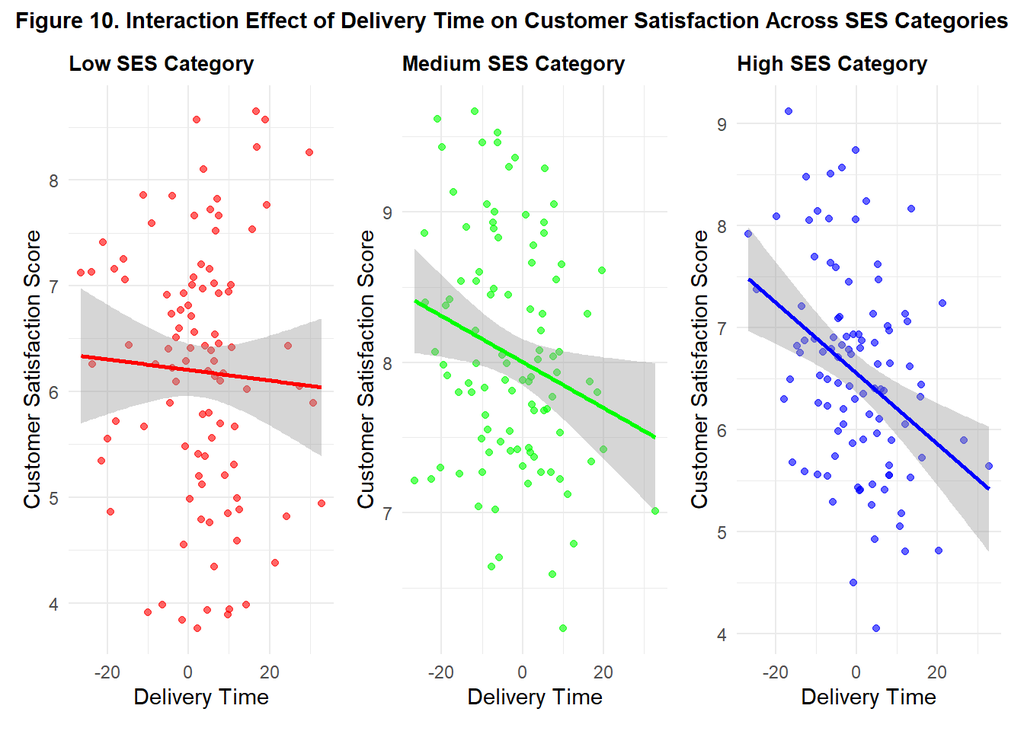

```r
# Visualize the interaction effect between delivery time and SES category on customer satisfaction
# Create individual plots for each SES category
plot_low <- ggplot(subset(cust_sat, ses_category_factor == "Low"),
                   aes(x = center_delivery_time, y = customer_satisfaction)) +
  geom_point(color = "red", alpha = 0.6) +
  geom_smooth(method = "lm", color = "red", se = TRUE) +
  labs(title = "Low SES Category",
       x = "Delivery Time",
       y = "Customer Satisfaction Score") +
  theme_minimal() +
  theme(plot.title = element_text(size = 10, face = "bold"))

plot_medium <- ggplot(subset(cust_sat, ses_category_factor == "Medium"),
                      aes(x = center_delivery_time, y = customer_satisfaction)) +
  geom_point(color = "green", alpha = 0.6) +
  geom_smooth(method = "lm", color = "green", se = TRUE) +
  labs(title = "Medium SES Category",
       x = "Delivery Time",
       y = "Customer Satisfaction Score") +
  theme_minimal() +
  theme(plot.title = element_text(size = 10, face = "bold"))

plot_high <- ggplot(subset(cust_sat, ses_category_factor == "High"),
                    aes(x = center_delivery_time, y = customer_satisfaction)) +
  geom_point(color = "blue", alpha = 0.6) +
  geom_smooth(method = "lm", color = "blue", se = TRUE) +
  labs(title = "High SES Category",
       x = "Delivery Time",
       y = "Customer Satisfaction Score") +
  theme_minimal() +
  theme(plot.title = element_text(size = 10, face = "bold"))

# Arrange the plots in a grid
plot_grid <- plot_low + plot_medium + plot_high +
  plot_annotation(title = "Figure 10. Interaction Effect of Delivery Time on Customer Satisfaction Across SES Categories",
                  theme = theme(plot.title = element_text(size = 11, hjust = 0.5, face = "bold")))

# Display the grid
print(plot_grid)
```

**Interpretation**: **Figure 10** illustrates how **delivery time** affects **customer satisfaction** differently across **Low, Medium, and High SES** groups.

In the **Low SES** group, the connection between delivery time and satisfaction is weak, as shown by the nearly flat **red trend line**. This suggests that delivery delays don’t significantly impact satisfaction in this group, although the wide **confidence interval** indicates some variability in responses.

In the **Medium SES** group, the relationship becomes clearer. The **green trend line** shows that longer delivery times lead to a noticeable drop in satisfaction, with a narrower **confidence interval**, indicating that this trend is more consistent.

For the **High SES** group, the impact of delivery time is the strongest. The steep **blue trend line** shows a significant drop in satisfaction as delivery times increase. This group is more sensitive to delays, and the narrow **confidence interval** highlights the consistency of this pattern.

Overall, the higher the **SES group**, the more strongly **customer satisfaction** is affected by **delivery delays**.

### *Conclusions*

Interestingly, introducing new **product ranges** doesn’t seem to affect customer satisfaction much. This could mean the new products aren’t aligning with customer preferences, so reconsidering **product selection** may be necessary.

In conclusion, **delivery time** and **staff satisfaction** are the most impactful drivers of customer satisfaction. Focusing on **faster delivery**, especially in **high SES areas**, and enhancing **employee engagement** could lead to significant improvements. Meanwhile, **product introductions** may need a new strategy to better meet customer expectations.